# The Synthetic Causal Framework

An NLP-based Solution to the Fundamental Problem of Causal Inference

Emil Meyer-Hansen[^1]

Version: 2024-10-16-15-16

# 1 Abstract

When testing theorized causal relationships, a *Randomized Controlled Trial* (RCT) is broadly considered the scientific golden standard for inferring causation, but this method requires the theorized cause to be manipulable. Researchers interested in a non-manipulable theorized cause are therefore unable to reliably draw causal inference. This recognized shortcoming has previously been addressed by methodologists, who have developed numerous alternatives that enable such researchers to draw causal inference. However, these methods often require untestable and dubious assumptions, and their applicability similarly varies. This can defeat their intended goal of providing *reliable* causal inference. This paper addresses these shortcomings by introducing a novel alternative: The *Synthetic Causal Framework* (SCF), which is widely applicable across disciplines and guarantees the high internal validity necessary for reliable causal inference. Formalized using the *Neyman-Rubin Potential Outcomes Framework* (Imbens and Rubin 2015), the SCF offers a *synthetic* solution to the *Fundamental Problem of Causal Inference* (Holland 1986) by estimating causal effects through intra-unit comparisons of counterfactual outcomes, enabling unbiased comparisons across any level of manipulation. This involves synthesizing simulated data and real-world data using Natural Language Processing (NLP) models, producing *synthetic units*, where each unit can be simultaneously exposed to all levels of manipulation. Causal inference can then be reliably drawn using standard statistical models. A proof-of-concept of the SCF is provided, in the form of a small-scale *Synthetically Controlled Trial* (SCT), which implements OpenAI’s GPT-4o-mini and Bayesian mixed effects models to successfully replicate the established relationship between social deservingness and welfare support (Aarøe and Petersen 2014; Kane et al. 2023; Mummolo and Peterson 2019). By replicating a robust human-based result solely using synthetic respondents, this provides evidence that SCF-based results can be generalized to human populations. Practical implications of the SCF are discussed, which includes the ability of researchers to generally and reliably draw causal inference when the theorized cause would normally be non-manipulable. A limitation of the SCF is the reliance on NLP-models that restricts its implementation to text-based environments. Other advantages include substantially reduced financial and time costs compared to human studies. While the generalizability of SCF-based results to human populations should remain a relevant concern, advances in the NLP-models are likely to reduce such concern and further increase the advantages of adopting the SCF for applied research.

**Keywords**: *Synthetic Causal Framework, SCF, Synthetically Controlled Trial, SCT, Causal inference, Causal framework, Causal methodology, Causal design, Experimental design, Potential Outcomes Framework, Fundamental Problem of Causal Inference, Natural Language Processing, NLP, Generative Pretrained Transformer, GPT, Political methodology, Political science, Social deservingness, Welfare support, Welfare attitudes, Evolutionary psychology, Conceptual replication*

# 2 Introduction

[Work-in-progress. Omitted in preview version.]

# 3 Theory

[Work-in-progress. Omitted in preview version.]

# 4 Methodology

To justify the *Synthetic Causal Framework* (SCF) empirically, as well as help researchers implement it, a proof-of-concept is provided in the form of a demonstration. This will specifically involve a small-scale replication of the established relationship between social deservingness and welfare support. The effect of social deservingness has been identified as positive, statistically discernible from zero ($p ≤ .05$), and practically significant ($r ≥ .3$, Funder and Ozer 2019) across multiple US-based studies (Aarøe and Petersen 2014; Kane et al. 2023; Mummolo and Peterson 2019), which employ *survey experiments* (Gaines et al. 2006) to achieve reliable causal inference. A *meta-analysis* (Eysenck 1995; Glass 1976; Sharpe and Poets 2020) is conducted on these studies using a *Bayesian mixed-effects model* (e.g., Maier et al. 2022), producing an estimated weighted average effect of .32 (SD = .07; 95% HDI[.16; .48]), which will be the exact effect to replicate. The following sections cover (1) the procedure for simulating data in a manner that makes respondent characteristics more representative of the US population; (2) how to use OpenAI’s API to call the gpt-4o-mini NLP-model (OpenAI 2024a) to transform the simulated respondents into *synthetic respondents* by generating life-histories, making their behavior less artificial and more human; (3) implementing a *Synthetically Controlled Trial* (SCT) and ‘parallel worlds’-estimation to unbiasedly measure each synthetic respondent’s counterfactual support for tightening welfare requirements when exposed to vignettes describing a ‘lazy’ or ‘unlucky’ welfare recipient; and (4) using statistical inference to estimate the causal effect of social (un)deservingness on welfare support. Following recommendations for reproducible and transparent research (e.g., Alister et al. 2021; Lenz and Sahn 2021; Open Science Collaboration 2015; Peng 2011; Ritchie 2021), this project subscribes to the *open science standard* (Christensen et al. 2019; Nosek et al. 2012, 2015), with this demonstration of the SCF being done with the free and open-source *R* programming language (R Core Team 2024) and *RStudio* IDE (Posit Team 2024), which is especially suited for data science (Welbers et al. 2017: 245) and reproducible research (Krotov and Tennyson 2018: 171). Accordingly, code for implementing this demonstration is provided as *R* syntax in the *markdown* (Gruber 2014) version of this file (not made available in this preview version), and software specifications, used *R* packages, and descriptive statistics of the data are provided in the appendix.

## 4.1 Simulating Data

As previously mentioned, simulating data allows the researcher to decide which characteristics the NLP-model should base its life-history and responses on. While OpenAI’s gpt-4o-mini is expectedly capable of inferring characteristics proportional to a population by basing them on their prevalence in its training data (OpenAI 2024a), explicitly determining the characteristics gives the researcher more control over the characteristics generated, which could impact the behavior of the synthetic respondents and how generalizable results are to the population of interest. While it can be expected that the greater the number of simulated characteristics, the more realistic the behavior of the NLP, in terms of specifically which and how many characteristics to simulate, answers to these questions will likely vary depending on characteristics found relevant for the particular research topic. For this demonstration, the common demographics (e.g., ANES 2021; Ruggles et al. 2024) of US State residence, area residence, number of children in household, sex, age, marital status, ethnoracial group[^2], highest level of education, employment status, and household income ($US) will be simulated, which will likely provide gpt-4o-mini with plenty of information to base its life-histories on. Furthermore, since the results from Aarøe and Petersen (2014), Mummolo and Peterson (2019), and Kane et al. (2023) relate specifically to *political* attitudes to welfare requirements, the characteristics of political party affiliation and political ideology will also be simulated.

Simulating characteristics can be done so that their prevalence in the data is proportional to a national population of interest. Since this demonstration focuses on the US-based results from Aarøe and Petersen (2014), and its replications by Mummolo and Peterson (2019) and Kane et al. (2023), the national population of interest is the adult population of the United States of America (US). A population-proportional simulation of characteristics can be achieved by constructing a *stratification matrix* using large samples such as those that form the basis of census data. A stratification matrix consists of every combination of the characteristics of interest and their frequency in the population, and a US-based version can be constructed using [US Census Bureau](https://www.census.gov/) data provided by the *IPUMS* (Ruggles et al. 2024). Here, the 2022-wave is especially useful for this project due to containing contemporary measures of most characteristics to simulate and a large sample size (*n*) of 3,373,378 respondents. However, the data lacks measures of political party affiliation and political ideology, meaning that these measures will have to be *imputed* (Kalton and Kasprzyk 1982; King et al. 2001; Rubin 1988).

To impute the measures of political party affiliation and political ideology, data from the similarly recent 2020-wave of the *American National Election Survey* (ANES 2021) can be used. While the ANES relies on samples substantially smaller than the IPUMS (*n* = 8,280), it contains similar measures of all characteristics to simulate. This can be used to train statistical models to impute political party and ideology by recoding all variables to have the same categories and scale across the IPUMS and ANES. Following the methodology of *cross-validation* (Stone 1974), an unbiased measure of the *imputation accuracy* of statistical models can be derived by splitting the ANES data into a train and test dataset, using the conventional 80/20 split ratio (e.g., França et al. 2024), training the models on the *training data* and testing their imputation accuracy on the *testing data*. To assess variability in imputation accuracy, *Bootstrapped (or Monte-Carlo) cross-validation* (Xu and Liang 2001) is used, which involves iteratively splitting and testing models a total of 10 times. To impute the dichotomously-coded preferred political party of respondents, a *Hierarchical Bernoulli* (Gelman and Hill 2007) and a *Random Forest* (Breiman 2001; Ho 1995; Liaw and Wiener 2002) model are compared. From their predictions, a *confusion matrix* (Tharwat 2018) is generated, with imputation accuracy being computed as the arithmetic mean of the *total accuracy* (ACC), *sensitivity* (i.e., *recall*) and *specificity* (Yerushalmy 1947), *positive predictive value* (PPV; i.e., *precision*) and *negative predictive value* (NPV) (Altman and Bland 1994), which are popular, complementary metrics of model accuracy. The imputation accuracy of the Hierarchical Bernoulli is .66, with a *standard deviation* (SD) of .01, while the Random Forest model has an imputation accuracy of .65 (SD = .01), meaning that the Hierarchical Bernoulli is chosen to impute political party in the IPUMS data due to its (marginally) superior accuracy. Imputing political ideology, which could be treated either as an ordered or (less appropriately) as a continuous variable, involves a *Hierarchical Gaussian* model (Gelman and Hill 2007), a *Generalized Additive Model* (GAM, Hastie and Tibshirani 1990; Wood 2004, 2011, 2017), and a Random Forest model. These are similarly evaluated, though given its non-dichotomous coding, only ACC is used to measure imputation accuracy. These models produce an ACC of .30 (.01), .30 (.01), and .43 (.01), respectively, resulting in the Random Forest model being chosen to impute political ideology for its superior accuracy.

Having imputed preferred political party and political idelogy in the IPUMS data, all chosen characteristics are available, and a stratification matrix is generated by counting the frequency of every combination of the characteristics. Then, analogous to a *non-parametric bootstrap* (Efron 1979, 2003), simulating data can done by sampling with replacement from the stratification matrix, with the sampling probability being the frequency of each combination of characteristics. This ensures that the value of each characteristic is simulated conditionally on the values of all the other characteristics (e.g., *P(sex = Male | State = Tennessee, Age = 65, Political Ideology = Conservative)*), making the resulting data reflect the proportionality of characteristics in the US population. Asymptotically, data simulated in this manner is representative of the national population of interest, and for smaller datasets that nonetheless are unrepresentative, the *multilevel regression and poststratification* (MRP, Gelman and Little 1997) method can be used to adjust for such sample-population imbalances. With this US-based stratification matrix available, a sample can then easily be generated. For the purposes of this brief demonstration, a small sample of 100 simulated respondents is generated, which, given that two counterfactual outcomes are observed for each respondent, provides an effective sample size of 200. With regard to succesfully replicating the aforementioned effect size of .32 with an $\alpha$ level of .05 and 2 model parameters (i.e., intercept and coefficient, see model below), the *statistical power* (Gelman and Carlin 2014) is 99.52%, which can be considered adequate (Cohen 1988, 1991). Similarly, the *type M error rate* (Gelman and Carlin 2014) is 1.00, meaning that the effect is unlikely to be under-/overestimated, while the *type S error rate* (Gelman and Carlin 2014) is .00%, indicating almost no probability of the estimate having the wrong sign. As such, the probability of a successful replication is high, at least as indicated by these metrics.

Table 4.1: Simulated Dataset

| id | State | Urban | Children | Sex | Age | Marital Status | Ethnoracial Group | Education | Employment Status | Household Income | Political Party | Political Ideology |
| --- | --- | --- | --- | --- | --- | --- | --- | --- | --- | --- | --- | --- |
| 1 | Tennessee | Small Town Or Surburb | 0 | Female | 65 | Married | White | Some Post-High School, No Bachelor’s Degree | Not In Labor Force | 41,400 | Republican Party | Conservative |
| 2 | Michigan | Small Town Or Surburb | 0 | Male | 68 | Married | White | Bachelor’s Degree | Not In Labor Force | 112,000 | Democratic Party | Slightly Liberal |
| 3 | Missouri | Small Town Or Surburb | 0 | Female | 69 | Widowed | White | High School Credential | Not In Labor Force | 38,400 | Republican Party | Moderate; Middle Of The Road |
| 4 | Indiana | Small Town Or Surburb | 2 | Female | 65 | Divorced | White | Bachelor’s Degree | Not In Labor Force | 23,000 | Democratic Party | Liberal |
| 5 | New York | Small Town Or Surburb | 0 | Female | 42 | Married | White | Bachelor’s Degree | Employed | 120,300 | Democratic Party | Moderate; Middle Of The Road |
| 6 | California | Small Town Or Surburb | 0 | Male | 59 | Married | White | Some Post-High School, No Bachelor’s Degree | Not In Labor Force | 35,000 | Republican Party | Conservative |

**NOTE**: Simulated data. n = 100. Household income is provided in 2022 US dollars ($). Based on data by the IPUMS (Ruggles et al. 2024) and ANES (2021).

This produces a 100 $\times$ 13 dataframe, with examples of observations in the dataframe being provided in table 4.1. The data contains an identification number (id) and the 12 measures of the selected characteristics of each simulated respondent: Their US state of residence (e.g., Missouri, Connecticut, Ohio), number of children (range: 0 - 3), sex (i.e., Female, Male), age (range: 18 - 86), marital status (e.g., Married, Not Married, Divorced), ethnoracial group (e.g., Puerto Rican, Filipino, Peruvian), level of education (range: Less Than High School Credential - Graduate Degree), employment status (e.g., Not In Labor Force, Unemployed, Employed), household income (range: 0 - 378,500; median: 77,750, $US), preferred political party (i.e., Republican Party, Democratic Party), and political ideology (range: Extremely Liberal - Extremely Conservative). For an overview, descriptive statistics are provided both metrically and graphically in the appendix.

While the sample, on average, manages to capture 91.74% (SD = 15.27*pp*) of the information in the US population[^3], an inspection of the distributions reveals some persisting differences, especially in preferred political party and ideology, where there is an overrepresentation of republicans and conservatives relative to the US population. Contrary to what was previously implied by the type M metric, this sample-population imbalance could cause an overestimated effect size, since the effect of social deservingness could interact with republicanism/conservatism, as democrats/liberals are expectedly more favorable of welfare support than republicans/conservatives, meaning that social deservingness likely matters more for the welfare support of conservatives than liberals. As such, the estimated *average* effect will likely be overestimated due to the overrepresentation of republican/conservative synthetic respondents, for whom the effect is expectedly larger. Nonetheless, these unrepresentative characteristics can be attributed not to sampling bias but to chance due to the relatively small sample size. Future studies can address such sample-population imbalances by generating larger samples with the stratification matrix to make data more representative. With this simulated data now having been generated, OpenAI’s (2024a) gpt-4o-mini can then be used to generate their life-histories.

## 4.2 Generating Life-Histories

With simulated data available, input can be engineered to prompt the NLP-model to generate life-histories for the respondents. A *life-history* (Rosenthal 2018) can be considered a narrative by which individuals (chronologically) frame their life, experiences, identity, relationships, existential purpose and place in society (e.g., Znaniecki and Thomas 2020[1974]). As previously mentioned, the purpose of life-histories is to provide more character and nuance to the simulated respondents in a way that goes beyond their assigned characteristics. This will expectedly help the NLP-model respond in a manner that is consistent with a human possessing the assigned characteristics, as human behavior is arguably more nuanced and complicated than what can be characterized by a relatively few set of characteristics. Prompting the NLP-model to generate the life-history based on their assigned characteristics helps ensure that other characteristics generated in the life-history are functions of the explicitly determined characteristics. An example of a contemporaneous iteration of a prompt useful for generating life-histories is provided in table 4.2.

Table 4.2: How To Generate A Life-History

| id | Prompt |
| --- | --- |
| 19 | You are to act as a character and must remain in character for the purposes of a roleplay scenario. ‘You’ and ‘your’ thus refer to your character from now on. Your character has the following characte… |

**NOTE**: The prompt was generated through trial-and-error and should be considered a non-authoritative and possibly suboptimal example of how to generate life-histories for simulated respondents using NLP-models. The characteristics in the prompt are based on data by the IPUMS (Ruggles et al. 2024) and ANES (2021).

The prompt aims to specify that the NLP-model is to act as a character and to persistently remain in character. This serves to ensure that all output generated by the NLP reflects behavior consistent with that character. It also contains a list of all the assigned characteristics, followed by a request for it to generate a (brief) life-history based on these characteristics. Increasing the number of provided characteristics and length of the generated life-history likely results in behavior that more realistically reflects a human possessing these traits, though at greater financial costs and time needed by the NLP-model to process the input and generate an output. The model’s *[max length](https://platform.openai.com/docs/api-reference/chat)* (i.e., `max_tokens`) parameter can be restricted to reduce costs (OpenAI 2024b), though this will likely reduce its ability to act in a manner consistent with its assigned characteristics. The optimal max length likely varies across different research purposes, and for this demonstration the `max_tokens` for generating life-histories is set to 500, which is found to be adequate within this context. Another OpenAI parameter is the *[temperature](https://platform.openai.com/docs/api-reference/chat)* (or randomness) of the NLP-model’s output. A higher value makes its output adhere less to language syntax, making its output less cohesive and meaningful. The default value by OpenAI is `1`, and while an optimal value will likely vary across contexts, this value is similarly found to be adequate for the context of generating life-histories in this demonstration.

To generate life-histories from the simulated data, it is recommended to use [OpenAI’s API](https://platform.openai.com/docs/api-reference/introduction). Requests processed through their API are not used to train their models and is deleted after 30 days (OpenAI 2024c), thus reducing concerns about privacy and whether prompt engineering inadvertently trains the model, resulting in findings that reflect researcher preferences rather than human behavior, possibly resulting in tautological results. Compared to manually generating life-histories, calling the API using software exponentially speeds up the process and is easily done through *R* in RStudio. To this end, this demonstration relies on the `openai` *R* package (Rudnytskyi 2023). Due to the speed of such software, it is furthermore recommended to enforce pauses between calls to the API to reduce traffic, which can stress their systems. OpenAI already enforces [rate limits](https://platform.openai.com/docs/guides/rate-limits), and to avoid unintentionally hitting one of their numerous request limitations (OpenAI 2024b), the researcher can *a priori* enforce a pause between requests. This demonstration uses a pause of 3.1 seconds, though values could vary depending on the number and length of requests.

This demonstration implements and recommends that NLP-output is generated separately for each simulated respondent. An alternative to this is *[batching](https://platform.openai.com/docs/api-reference/batch)*, which involves grouping multiple requests together into a single request (OpenAI 2024b). For example, by providing the characteristics of several simulated respondents in the same prompt and asking for multiple life-histories. While this can reduce both financial and time costs, a serious methodological concern of batching is that generating life-histories (and most other types of outcome) in batches produces output that is interdependent, which typically is not desirable. For example, output generated in batches may be more strongly correlated than output generated in other batches or output generated individually. This would violate the common statistical assumption of observations being *identically and independently distributed* (*iid*, Gaenssler and Stute 1979), which will likely need to be adjusted for using statistical modeling (e.g., hierarchical models, Gelman and Hill 2007). Furthermore, when generating the outcome across different group conditions using batching, there may be information *spill-over*, for example, if the NLP-model mistakes a manipulated with a non-manipulated unit or if the mere presence of information relating to both group conditions affects the generation of results. This spill-over would violate the assumption of *stable unit treatment value assumption* (SUTVA, Cox 1958; Gelman et al. 2021: 353-354; Rosenbaum and Rubin 1983; Rubin 1974), which is fundamental to causal inference (Angrist et al. 1996; Imbens and Rubin 2015: 9-12). While methods could be implemented to account for this information spill-over (Imbens and Rubin 2015: 12-13; e.g., Aronow and Samii 2017), these can be complex (Rosenbaum 2007), and as similarly argued by Elizabeth Stuart (2010: 3), the most effective solution is simply to prevent interdependency and spill-over by design. As such, to prevent violations of *iid* and SUTVA in this manner, it is recommended to generate life-histories and most other types of outcome separately, unless the purpose specifically is to study interdependency.

With the specifications and considerations in mind, a life-history for each simulated resondent can be generated. In this demonstration, this involves a for-loop, which iteratively goes through each respondent, makes a call to OpenAI’s API for the selected gpt-4o-mini NLP-model, and saves the output to the data. The loop accounts for possible errors in calling the API by waiting 10 seconds before trying again. Information about the output generation provided by OpenAI is saved, such as the time of the request, which help provide documentation of the data. The number of tokens used and the time it took to generate the output is also stored, which will be used to ascertain financial and time costs. Note that before it is possible to call OpenAI’s API, researchers must create an OpenAI account, deposit finances, and generate a unique [API key](https://platform.openai.com/docs/api-reference/authentication) (OpenAI 2024b). The key will be used to connect your requests with your finances and should thus be kept private. Following this, the below *R* code for the for-loop can be executed:

```r
# Initialize columns for storing the GPT-output
simulated_data$life_history_gpt <- NA
simulated_data$life_history_id_gpt <- NA
simulated_data$life_history_object_gpt <- NA
simulated_data$life_history_created_gpt <- NA
simulated_data$life_history_model_gpt <- NA
simulated_data$life_history_prompt_tokens <- NA
simulated_data$life_history_completion_tokens <- NA
simulated_data$life_history_logprobs <- NA
simulated_data$life_history_finish_reason <- NA
simulated_data$life_history_message.refusal <- NA
simulated_data$life_history_message.role <- NA
simulated_data$life_history_time_cost <- NA


# Construct prompt
messages_life_history <- list()
messages_life_history[[1]] <- list(
  "role" = "system",
  "content" = "You are a human simulator."
)
messages_life_history[[2]] <- list(
  "role" = "user",
  "content" = NA
)


# A progress bar is useful for keeping track of the progress of the loop
pb <- txtProgressBar(min = 0, max = nrow(simulated_data), style = 3)


# The for-loop
for(i in 1:nrow(simulated_data)){

  # Start time recording
  t0 <- Sys.time()


  # Enforce a pause if this is the second iteration or higher
  if(i > 1){
    Sys.sleep(pause_duration)
  }


  # Adjust prompt to reflect respondent i's characteristics
  messages_life_history[[2]][2] <- list(paste0(
    "You are to act as a character and must remain in character for the purposes of a roleplay scenario. 'You' and 'your' thus refer to your character from now on. Your character has the following characteristics:
    Country: United States of America (USA)
    State: ", simulated_data$state[i], "
    Urban: ", simulated_data$urban[i], "
    Number of Children in Household: ", simulated_data$children[i], "
    Sex: ", simulated_data$sex[i], "
    Age: ", simulated_data$age[i], "
    Marriage Status: ", simulated_data$married[i], "
    Race/Ethnicity: ", simulated_data$race_d[i], "
    Household Income: ", simulated_data$household_income_d[i], "
    Education: ", simulated_data$education[i], "
    Employment Status: ", simulated_data$employment[i], "
    Preferred Political Party: ", simulated_data$political_party[i], "
    Political Ideology: ", simulated_data$political_ideology[i], "
    Be creative but realistic and compose a brief life-history for your character based on the provided characteristics:"
  ))


  # Call GPT model (and use tryCatch to make the loop continue retrying if encountering an error)
  while(TRUE){
    tryCatch(
      expr = {
        gpt_output <- openai::create_chat_completion(
          model = selected_gpt_model,
          messages = messages_life_history,
          max_tokens = max_tokens$life_history,
          temperature = temperature$life_history,
          openai_api_key = OPENAI_API_KEY
        )
      },
      error = function(e){
        print(paste("Error encountered. Error message:", e))
        print(" Going to sleep for 10 seconds ...")
        Sys.sleep(time = 10)
      }
    )
    break
  }


  # Store life history
  simulated_data$life_history_gpt[i] <- gpt_output$choices$message.content


  # Store utility info
  simulated_data$life_history_id_gpt[i] <- gpt_output$id
  simulated_data$life_history_object_gpt[i] <- gpt_output$object
  simulated_data$life_history_created_gpt[i] <- gpt_output$created
  simulated_data$life_history_model_gpt[i] <- gpt_output$model
  simulated_data$life_history_prompt_tokens[i] <- gpt_output$usage$prompt_tokens
  simulated_data$life_history_completion_tokens[i] <- gpt_output$usage$completion_tokens
  simulated_data$life_history_logprobs[i] <- gpt_output$choices$logprobs
  simulated_data$life_history_finish_reason[i] <- gpt_output$choices$finish_reason
  simulated_data$life_history_message.refusal[i] <- gpt_output$choices$message.refusal
  simulated_data$life_history_message.role[i] <- gpt_output$choices$message.role


  # Update progress bar
  setTxtProgressBar(pb, i)


  # End and store time recording
  t1 <- Sys.time()
  simulated_data$life_history_time_cost <- t1-t0
}


# Convert Unix Timestamp to Datatime
simulated_data$life_history_datetime <- as_datetime(simulated_data$life_history_created_gpt)
```

Using the aforementioned specifications, generating 100 life-histories using this for-loop takes 15.00 minutes, with the expected time-cost per simulated respondent thus being 9.00 (SD = .00) seconds. Output from the gpt-4o-mini model can be gauged to ascertain whether it ran into any [issues](https://platform.openai.com/docs/api-reference/debugging-requests) during the generation (OpenAI 2024b). This includes its `finish_reason`, where `stop` is consistent with no issues, while `length` means that the life-histories were cut short due to the model reaching the specified `max_tokens` limitation. Another output parameter is `message.refusal`, which indicates whether the model refused to provide an output, and this should generally equal `NA`. A message refusal can happen for several reasons and retries or changing the input may fix the issue. To provide more intuition about a life-history, an example is provided in table 4.3.

Table 4.3: Example of a Generated Life-History

| id | Life-History |
| --- | --- |
| 19 | My name is Sofia Martinez, and I’ve spent my entire life here in a small town in Arkansas. At 53, I look back on a journey marked by both challenges and triumphs. Growing up, my parents immigrated fro… |

**NOTE**: The respondent’s life-history was synthetically generated by OpenAI’s (2024a) gpt-4o-mini model on 2024-09-20 14:47:09 using simulated characteristics based on data by the IPUMS (Ruggles et al. 2024) and ANES (2021).

It is here recommended to validate that the life-histories reflect and are consistent with the assigned characteristics. This serves to ensure that future output by the model correctly draws on the assigned characteristics. Analogous to qualitative methodology or *computational text analysis* (Theocharis and Jungherr 2021), validations can be performed by *coders*, who read the generated life-history and compare it to the assigned characteristics. Coders can provide their evaluations of consistency in numerous formats, for example, dichotomously (e.g., ‘Consistent’, ‘Inconsistent’), continuously (e.g., 5-point Likert scale), or in open-text format. The number of coders and evaluated life-histories can vary, for example, two independent coders, who evaluate all life-histories or a random sample, with the scope of the evaluation likely depending on the resources available for the given project. Coder evaluations can then be assessed to ascertain their *inter-coder reliability* (Saal et al. 1980), which expresses whether coders are generally in agreement on the (in)consistency of the output. If coder evaluations are provided in a quantifiable format, this can be estimated as a reliability coefficient, for example, as *percent agreement*, Sklar’s $\omega$ (Hughes 2022), Krippendorff’s $\alpha$ (2018), Fleiss’ $\kappa$ (1971), Cohen’s $\kappa$ (1960), Scott’s $\pi$ (1955), Spearman’s $\rho$ (1904), Kendall’s τ (1938), or Pearson-Galton’s *r* (Pearson 1895a)[^4], depending on the number of coders and the scale used to measure (in)consistency. If the same coder has evaluated the same output multiple times, *intra-coder reliability* (Saal et al. 1980) can also be similarly estimated. An alternative procedure to human coders is to have NLP-models act as coders, which can reduce financial and time costs related to evaluating the consistency of the model output. If doing this, it can be specified that `temperature = 0`, which increases the determinism of the NLP-coders, expectedly producing a perfect inter- and intra-coder reliability. However, this may under-/overestimate consistency and caution in choosing to use NLP-coders is advised, as it reduces human supervision and quality control over the output.

With life-histories now generated from the simulated characteristics, this synthesis of simulated data and NLP-based data can be considered to have produced synthetic data, which enables a more realistic investigation of the effect of social-deservingness on welfare support. This allows a *Synthetically Controlled Trial* (SCT) to be conducted, with the purpose being the simultaneous measurement of the counterfactual outcomes for all synthetic respondents.

## 4.3 Conducting an SCT

With synthetic data having been produced through the synthesis of simulated data and NLP-based data, a *Synthetically Controlled Trial* (SCT) can then be conducted to generate and measure both potential outcomes of all synthetic respondents, producing an unbiased and reliable estimate of the causal effect of social-deservingness on welfare support. The following subsections cover (1) the simultaneous generation and measurement of the potential outcomes across a treatment and control condition; (2) an assessment of (im)balance between the measured characteristics of the synthetic respondents across the group conditions, revealing perfect balance; (3) a statistical test of the *simultaneity assumption* to ascertain whether time could confound results; and (4) a formalization of the statistical model, which in line with Bayesian inference will be used to estimate the causal effect of social-deservingness on welfare support.

### 4.3.1 Parallel Worlds

Generating potential outcomes is similar to the procedure used for generating life-histories. This will involve prompting the NLP-model to assume the character of the synthetic respondent by relying on the characteristics described in the previously generated life-histories. As mentioned, the *Synthetically Controlled Trial* (SCT) gets its name from *Randomized Controlled Trials* (RCTs, Coover and Angell 1907; Peirce and Jastrow 1885; Woodworth and Thorndike 1901), since its borrows heavily on its methodology and can be considered its synthetic counterpart. Just like an RCT, the SCT will involve assigning the synthetic respondents to group conditions with varying manipulations, followed by measuring the outcome. However, an SCT does not rely on randomized manipulation assignment, since every respondent can be assigned to every manipulation condition and have all their counterfactual outcomes measured. This involves simultaneously assigning each synthetic respondent to each group condition, ensuring that for each group assignment, no information about other group conditions are present, eliminating pre- or posttreatment bias that would otherwise need to have been accounted for. To avoid time being a possible confounder, it is important that this process, at least with respect to each synthetic respondent, occurs simultaneously across group conditions, which is termed the *simultaneity assumption*. Compliance with this assumption is implemented with the novel concept of ‘parallel worlds’-estimation, which exploits *parallel computation* (Gottlieb and Almasi 1989; Ozdoganlar and Endres 2021[1999]) to simultaneously generate and measure the counterfactual outcomes of each respondent by handling these processes in separate computational cores. If the simultaneity assumption is not violated, this will remove time as a confounder, though ‘parallel worlds’-estimation requires implementation on a machine that has as many computational cores as there are manipulation conditions.

Figure 4.1: Relationship Between Social Deservingness & Welfare Support

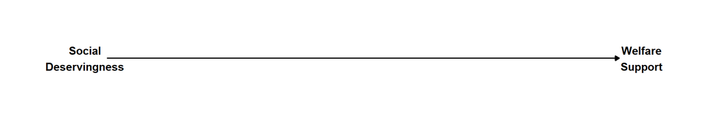

**NOTE**: Directed Acyclic Graph (e.g., Pearl 1988, 1993, 1995). Theorized causal relationship based on (Aarøe and Petersen 2014).

With the above considerations in mind, the current demonstration involves replicating the results by Aarøe and Petersen (2014), Mummolo and Peterson (2019), and Kane et al. (2023). As mentioned, these have established the causal effect of social deservingness on welfare support, which this demonstration is interested in replicating. For ease of overview, this relationship is provided graphically in figure 4.1. To test this relationship, the studies use vignettes to manipulate the level of social deservingness of a fictitious welfare recipient shown to the respondents. In this demonstration, two of their three manipulation conditions are replicated, which involve the vignettes describing a ‘Lazy Welfare Recipient’ and an ‘Unlucky Welfare Recipient’, which they task the respondent with imagining before responding ‘To what extent do you disagree or agree that the eligibility requirements for social welfare should be tightened for persons like him?’ (Aarøe and Petersen 2014). For simplicity, the former manipulation condition will be referred to as the ‘control’ condition, while the latter will be the ‘treatment’ condition. These vignettes can be reformulated as *prompts* (e.g., Ornstein et al. 2024), which are provided in table 4.4. The prompt adds realism-promoting context for the synthetic respondent, such as the notion that the respondent has chosen to participate in a survey and has already filled out questions regarding their background characteristics. This includes some standard survey introductory text that informs the respondent that the researchers are impartial and professional and care for the respondent’s honest answers. This flavor text serves to reduce the impact of *social desirability* (Edwards 1953; Krumpal 2013) and other *demand characteristics* (Masling 1966; Nichols and Maner 2008), such as *expectancy effects* (McDermott 1895: 34) and *experimenter demand bias* (Druckman 2015: 57-58), on respondent answers. The prompts include the response scale, since it is important to provide the NLP-model with the intended response format. In line with the replication, a 5-point Likert (1932) scale is used, however, other types of scales may be of greater use to capture other phenomena. Lastly, the prompt explicitly states that the respondent takes their time to imagine the welfare recipient, which serves to ensure that the response reflects a contemplated opinion. However, as empirical researchers are aware, not all human respondents take their time to read and comply with vignettes (Kane et al. 2023), and given how agreeable the GPT models generally are, it is likely that the responses will fail to reflect non-compliant and inattentive human respondents.

Table 4.4: Group Conditions

| Control (‘Lazy Recipient’) | Treatment (‘Unlucky Recipient’) |
| --- | --- |
| One day you decide to participate in a survey. You are informed that the responsible researchers are professional and impartial and care about your honest opinions. On the first few pages, you answer … | One day you decide to participate in a survey. You are informed that the responsible researchers are professional and impartial and care about your honest opinions. On the first few pages, you answer … |

**NOTE**: The prompt was generated through trial-and-error and should be considered a non-authoritative and possibly suboptimal example of how to generate manipulation conditions for synthetic respondents using NLP-models. Wording of group conditions are based on (Aarøe and Petersen 2014).

With one vignette being used in each manipulation condition, the synthetic respondents can then be simultaneously assigned to both conditions to provide their counterfactual responses. Similar to generating the life-histories, this again involves a for-loop iterating over each synthetic respondent, thus abiding by the *iid* and SUTVA assumptions. Unlike before, however, the loop implements a nested for-loop that implements the ‘parallel worlds’-estimation using parallel processing (Microsoft and Weston 2022b). This is applied when assigning a synthetic respondent to the manipulation conditions, where in each core, a call to OpenAI’s API (2024a) of the gpt-4o-mini model is made, producing two independent API calls. As mentioned, this serves to reduce any time difference between observing each outcome across the manipulation conditions. Outside this parallel process, API calls are made continuously with a 3.1 second pause between each synthetic respondent, and a 10-second pause in case of an error. It should be further noted that a random Bernoulli-process determines which manipulation condition is first initialized in the parallel process, which serves to ensure that any idiosyncratic waits attributable to the initiating value are unbiased.

The below for-loop generates both counterfactual outcomes for each respondent, one for the ‘Lazy Welfare Recipient’ and one for the ‘Unlucky Welfare Recipient’. The implementation of the ‘parallel worlds’-estimation procedure uses two independent cores, with one core being used to process each manipulation condition.

```r
# Initialize columns for factual outcome
simulated_data$outcome_gpt <- NA
simulated_data$outcome_id_gpt <- NA
simulated_data$outcome_object_gpt <- NA
simulated_data$outcome_created_gpt <- NA
simulated_data$outcome_model_gpt <- NA
simulated_data$outcome_prompt_tokens <- NA
simulated_data$outcome_completion_tokens <- NA
simulated_data$outcome_logprobs <- NA
simulated_data$outcome_finish_reason <- NA
simulated_data$outcome_message.refusal <- NA
simulated_data$outcome_message.role <- NA


# Initialize columns for counterfactual outcome
simulated_data$outcome_counterfactual_gpt <- NA
simulated_data$outcome_counterfactual_id_gpt <- NA
simulated_data$outcome_counterfactual_object_gpt <- NA
simulated_data$outcome_counterfactual_created_gpt <- NA
simulated_data$outcome_counterfactual_model_gpt <- NA
simulated_data$outcome_counterfactual_prompt_tokens <- NA
simulated_data$outcome_counterfactual_completion_tokens <- NA
simulated_data$outcome_counterfactual_logprobs <- NA
simulated_data$outcome_counterfactual_finish_reason <- NA
simulated_data$outcome_counterfactual_message.refusal <- NA
simulated_data$outcome_counterfactual_message.role <- NA


# Initialize column for time recording
simulated_data$outcome_time_cost <- NA


# Call the selected GPT-model through OpenAI's API to generate outcomes for the simulated respondents
pb <- txtProgressBar(min = 0, max = nrow(simulated_data), style = 3)

t0 <- Sys.time()
for(i in 1:nrow(simulated_data)){

  # Start time recording
  t0 <- Sys.time()


  # Pause
  if(i > 1){
    Sys.sleep(pause_duration)
  }


  # Adjust prompt to respondent life-history
  message_history <- list(
    list(
      "role" = "system",
      "content" = "You are a human survey respondent."
    ),
    list(
      "role" = "assistant",
      "content" = simulated_data$life_history_gpt[i]
    ),
    list(
      "role" = "user",
      "content" = NA
    )
  )

  # Use parallel processing to 'create parallel worlds', where each respondent is assigned to either condition and have their outcome measured. In case of errors or delays, use randomization to decide what condition to 'start' with
  if(rbinom(1, 1, .5)){
    gpt_results <- foreach(j = 1:2, .combine = "rbind") %dopar% {
      message_history[[3]]$content <- group_condition[[j]]$content

      # Call GPT model (and retry if encountering an error)
      while(TRUE){
        tryCatch(
          expr = {
            gpt_output <- openai::create_chat_completion(
              model = selected_gpt_model,
              messages = message_history,
              max_tokens = max_tokens$outcome,
              temperature = temperature$outcome,
              openai_api_key = OPENAI_API_KEY
            )
          },
          error = function(e){
            print(paste("Error encountered. Error message:", e))
            print(" Going to sleep for 10 seconds ...")
            Sys.sleep(time = 10)
          }
        )
        break
      }

      data.frame(
        condition =  group_condition[[j]]$condition,
        gpt_output = gpt_output
      )
    }
  }else{
    gpt_results <- foreach(j = 2:1, .combine = "rbind") %dopar% {
      message_history[[3]]$content <- group_condition[[j]]$content

      # Call GPT model (and retry if encountering an error)
      while(TRUE){
        tryCatch(
          expr = {
            gpt_output <- openai::create_chat_completion(
              model = selected_gpt_model,
              messages = message_history,
              max_tokens = max_tokens$outcome,
              temperature = temperature$outcome,
              openai_api_key = OPENAI_API_KEY
            )
          },
          error = function(e){
            print(paste("Error encountered. Error message:", e))
            print(" Going to sleep for 10 seconds ...")
            Sys.sleep(time = 10)
          }
        )
        break
      }

      data.frame(
        condition =  group_condition[[j]]$condition,
        gpt_output = gpt_output
      )
    }
  }


  # Store Outcome
  simulated_data$outcome_gpt[i] <- gpt_results$gpt_output.choices.message.content[gpt_results$condition == "lazy"]


  # Store Utility info
  simulated_data$outcome_id_gpt[i] <- gpt_results$gpt_output.id[gpt_results$condition == "lazy"]
  simulated_data$outcome_object_gpt[i] <- gpt_results$gpt_output.object[gpt_results$condition == "lazy"]
  simulated_data$outcome_created_gpt[i] <- gpt_results$gpt_output.created[gpt_results$condition == "lazy"]
  simulated_data$outcome_model_gpt[i] <- gpt_results$gpt_output.model[gpt_results$condition == "lazy"]
  simulated_data$outcome_prompt_tokens[i] <- gpt_results$gpt_output.usage.prompt_tokens[gpt_results$condition == "lazy"]
  simulated_data$outcome_completion_tokens[i] <- gpt_results$gpt_output.usage.completion_tokens[gpt_results$condition == "lazy"]
  simulated_data$outcome_logprobs[i] <- gpt_results$gpt_output.choices.logprobs[gpt_results$condition == "lazy"]
  simulated_data$outcome_finish_reason[i] <- gpt_results$gpt_output.choices.finish_reason[gpt_results$condition == "lazy"]
  simulated_data$outcome_message.refusal[i] <- gpt_results$gpt_output.choices.message.refusal[gpt_results$condition == "lazy"]
  simulated_data$outcome_message.role[i] <- gpt_results$gpt_output.choices.message.role[gpt_results$condition == "lazy"]



  # Store Counterfactual outcome_counterfactual
  simulated_data$outcome_counterfactual_gpt[i] <- gpt_results$gpt_output.choices.message.content[gpt_results$condition == "unlucky"]


  # Store Utility info
  simulated_data$outcome_counterfactual_id_gpt[i] <- gpt_results$gpt_output.id[gpt_results$condition == "unlucky"]
  simulated_data$outcome_counterfactual_object_gpt[i] <- gpt_results$gpt_output.object[gpt_results$condition == "unlucky"]
  simulated_data$outcome_counterfactual_created_gpt[i] <- gpt_results$gpt_output.created[gpt_results$condition == "unlucky"]
  simulated_data$outcome_counterfactual_model_gpt[i] <- gpt_results$gpt_output.model[gpt_results$condition == "unlucky"]
  simulated_data$outcome_counterfactual_prompt_tokens[i] <- gpt_results$gpt_output.usage.prompt_tokens[gpt_results$condition == "unlucky"]
  simulated_data$outcome_counterfactual_completion_tokens[i] <- gpt_results$gpt_output.usage.completion_tokens[gpt_results$condition == "unlucky"]
  simulated_data$outcome_counterfactual_logprobs[i] <- gpt_results$gpt_output.choices.logprobs[gpt_results$condition == "unlucky"]
  simulated_data$outcome_counterfactual_finish_reason[i] <- gpt_results$gpt_output.choices.finish_reason[gpt_results$condition == "unlucky"]
  simulated_data$outcome_counterfactual_message.refusal[i] <- gpt_results$gpt_output.choices.message.refusal[gpt_results$condition == "unlucky"]
  simulated_data$outcome_counterfactual_message.role[i] <- gpt_results$gpt_output.choices.message.role[gpt_results$condition == "unlucky"]


  # Update progress bar
  setTxtProgressBar(pb, i)


  # End and store time recording
  t1 <- Sys.time()
  simulated_data$outcome_time_cost <- t1-t0
}


# Convert Unix Timestamp to Datatime
simulated_data$outcome_datetime <- as_datetime(simulated_data$outcome_created_gpt)
simulated_data$outcome_counterfactual_datetime <- as_datetime(simulated_data$outcome_counterfactual_created_gpt)
```

Executing the above for-loop, generating the control (“Lazy Recipient”) and treatment (“Unlucky Recipient”) outcomes for each of the 100 synthetic respondents, takes a total of 8.54 minutes. This means that for these specified settings, the expected time-cost per simulated respondent is 5.13 (SD = .00) seconds. Following this, the generated outcomes can the be examined to ascertain whether the intended output has been generated and if the model ran into any issues generating it. Similar to the generated life-histories, this could involve using coders to check for consistency between the responses and the life-histories/characteristics. An example of a synthetic respondent with both counterfactual outcomes observed is provided in table 4.5.

Table 4.5: Example of Observing Both Potential Outcomes

| id | Control Outcome (‘Lazy Recipient’) | Treatment Outcome (‘Unlucky Recipient’) |
| --- | --- | --- |
| 19 | I would select “2 Disagree.” While I understand the concerns about eligibility requirements for social welfare, I believe that support systems should be in place to help individuals in need, regardles… | 1 Strongly disagree. I believe that individuals who are genuinely motivated to return to work, especially those who have faced unexpected challenges like a work-related injury, should have access to s… |

**NOTE**: These respondent answers were synthetically generated by OpenAI’s (2024a) gpt-4o-mini model on 2024-09-20 15:09:26 in response to vignettes and questions created by (Aarøe and Petersen 2014), using simulated characteristics based on data by the IPUMS (Ruggles et al. 2024) and ANES (2021).

The provided example gives an overview of the expected output produced by the gpt-4o-mini model, which can consist of responses of varying length and concision that may not be as easily processed as data generated by human respondents in a survey. This may not be an issue if the researcher wants to analyze the output in a qualitative manner, however, data can otherwise be converted to a format more easily processed quantitatively by extracting responses that fit with the intended response scale. Since Aarøe and Petersen (2014) treat the 5-point Likert scale (inappropriately, Göb et al. 2007; Lantz 2013; Wu and Leung 2017) as *interval*-scaled (Stevens 1932), this replication similarly converts the outcome to a numeric format for linear analysis. For an overview of the response distribution, descriptive statistics are provided metrically and graphically in the appendix. Following this, the group balance in synthetic respondent characteristics can then be assessed.

### 4.3.2 Group Balance

This paper has so far argued that implementing the Synthetic Causal Framework as a Synthetically Controlled Trial ensures perfect balance in the respondent characteristics across manipulation conditions. To empirically prove this (Stuart 2010), this subsection assesses the balance. This is done across all simulated characteristics, comparing their averages or frequencies across the control (‘Lazy Recipient’) and the treatment (‘Unlucky Recipient’) group conditions. Estimates of group differences are provided, including the log-odds of being assigned the treatment (‘Unlucky Recipient’) group condition conditional on the characteristics, computed using a Frequentist *logistic Bernoulli model* (Berkson 1944; Cox 1958; Pearl and Reed 1920; Verhulst 1838) that uses mixed effects to account for each synthetic respondent being observed in both manipulation conditions. The theoretical expectation is that since each individual is assigned to each manipulation condition, there will be a perfect balance between groups and the log-odds of treatment will be 0, meaning that the probability of being assigned to either the control (‘Lazy Recipient’) or treatment (‘Unlucky Recipient’) group condition is 50/50. The results are provided in table 4.6.

Table 4.6: Balance Table

| Characteristic | Treatment (‘Unlucky Recipient’) | Control (‘Lazy Recipient’) | Difference | Log-Odds of Treatment |
| --- | --- | --- | --- | --- |
| Females - Ratio | 0.530 | 0.530 | 0 | .000 (.000) |
| Age - Mean | 53.250 | 53.250 | 0 | .000 (.000) |
| Household Income - Mean | 94,276.600 | 94,276.600 | 0 | .000 (.000) |
| Republicans - Ratio | 0.590 | 0.590 | 0 | .000 (.000) |
| Conservatism - Mean | 0.582 | 0.582 | 0 | .000 (.000) |
| Less Than High School Credential | 7.000 | 7.000 | 0 | Ref. |
| High School Credential | 31.000 | 31.000 | 0 | .000 (.000) |
| Some Post-High School, No Bachelor’s Degree | 29.000 | 29.000 | 0 | .000 (.000) |
| Bachelor’s Degree | 23.000 | 23.000 | 0 | .000 (.000) |
| Graduate Degree | 10.000 | 10.000 | 0 | .000 (.000) |
| 0 Children | 69.000 | 69.000 | 0 | Ref. |
| 1 Child | 14.000 | 14.000 | 0 | .000 (.000) |
| 2 Children | 14.000 | 14.000 | 0 | .000 (.000) |
| 3 Children | 3.000 | 3.000 | 0 | .000 (.000) |
| 4 Or More Children | 0.000 | 0.000 | 0 | Dropped* |
| Married | 58.000 | 58.000 | 0 | Ref. |
| Divorced | 11.000 | 11.000 | 0 | .000 (.000) |
| Not Married | 20.000 | 20.000 | 0 | .000 (.000) |
| Widowed | 11.000 | 11.000 | 0 | .000 (.000) |
| White | 80.000 | 80.000 | 0 | Ref. |
| Black/African American | 3.000 | 3.000 | 0 | .000 (.000) |
| Chinese | 3.000 | 3.000 | 0 | .000 (.000) |
| Cuban | 2.000 | 2.000 | 0 | .000 (.000) |
| Filipino | 1.000 | 1.000 | 0 | .000 (.000) |
| Mexican | 5.000 | 5.000 | 0 | .000 (.000) |
| Peruvian | 1.000 | 1.000 | 0 | Dropped* |
| Puerto Rican | 2.000 | 2.000 | 0 | .000 (.000) |
| Venezuelan | 1.000 | 1.000 | 0 | .000 (.000) |
| Vietnamese | 2.000 | 2.000 | 0 | .000 (.000) |
| Employed | 53.000 | 53.000 | 0 | Ref. |
| Not In Labor Force | 44.000 | 44.000 | 0 | .000 (.000) |
| Unemployed | 3.000 | 3.000 | 0 | .000 (.000) |
| California | 9.000 | 9.000 | 0 | Ref. |
| Alabama | 2.000 | 2.000 | 0 | .000 (.000) |
| Arkansas | 4.000 | 4.000 | 0 | .000 (.000) |
| Colorado | 2.000 | 2.000 | 0 | .000 (.000) |
| Connecticut | 3.000 | 3.000 | 0 | .000 (.000) |
| Delaware | 1.000 | 1.000 | 0 | .000 (.000) |
| Florida | 8.000 | 8.000 | 0 | .000 (.000) |
| Georgia | 1.000 | 1.000 | 0 | .000 (.000) |
| Illinois | 3.000 | 3.000 | 0 | .000 (.000) |
| Indiana | 2.000 | 2.000 | 0 | .000 (.000) |
| Iowa | 1.000 | 1.000 | 0 | .000 (.000) |
| Kansas | 1.000 | 1.000 | 0 | .000 (.000) |
| Kentucky | 1.000 | 1.000 | 0 | .000 (.000) |
| Maryland | 1.000 | 1.000 | 0 | .000 (.000) |
| Massachusetts | 1.000 | 1.000 | 0 | .000 (.000) |
| Michigan | 3.000 | 3.000 | 0 | .000 (.000) |
| Minnesota | 3.000 | 3.000 | 0 | .000 (.000) |
| Mississippi | 2.000 | 2.000 | 0 | .000 (.000) |
| Missouri | 3.000 | 3.000 | 0 | .000 (.000) |
| Nevada | 1.000 | 1.000 | 0 | .000 (.000) |
| New York | 3.000 | 3.000 | 0 | .000 (.000) |
| North Carolina | 7.000 | 7.000 | 0 | .000 (.000) |
| Ohio | 5.000 | 5.000 | 0 | .000 (.000) |
| Oregon | 1.000 | 1.000 | 0 | .000 (.000) |
| Pennsylvania | 4.000 | 4.000 | 0 | .000 (.000) |
| South Dakota | 1.000 | 1.000 | 0 | .000 (.000) |
| Tennessee | 2.000 | 2.000 | 0 | .000 (.000) |
| Texas | 12.000 | 12.000 | 0 | .000 (.000) |
| Vermont | 1.000 | 1.000 | 0 | .000 (.000) |
| Washington | 6.000 | 6.000 | 0 | .000 (.000) |
| West Virginia | 1.000 | 1.000 | 0 | .000 (.000) |
| Wisconsin | 4.000 | 4.000 | 0 | .000 (.000) |
| Wyoming | 1.000 | 1.000 | 0 | .000 (.000) |
| Sample Size | 100.000 | 100.000 | 0 | NA |

**NOTE**: Group value comparisons with bootstrapped standard errors in parentheses. Non-parametric bootstrapped permutations = 1,000. *Dropped by `lme4` software (Bates et al. 2015) due to rank deficiency in the model. Synthetic data, with group conditions based on (Aarøe and Petersen 2014) and characteristics based on data by the IPUMS (Ruggles et al. 2024) and ANES (2021).

The balance table reveals that there are no differences in any of the synthetic respondent characteristics across the manipulation conditions, meaning that results cannot be confounded by these characteristics (Stuart 2010). That there is perfect balance is further validated by taking the sum of differences and testing whether it is equal to 0, which is indeed found to be true. Similarly, the log-odds of receiving treatment conditional on the characteristics is 0, with effectively no estimation uncertanty. Accordingly, there is perfect sample balance on the measured characteristics, and given that there are no ‘statistically significant’ differences (Mutz and Pemantle 2012: 3), this procedure for generating perfect balance can be expected to produce similarly perfect balances in other samples as well.

While the balance table only demonstrates perfect balance on the measured characteristics, given that every synthetic respondent is assigned to both manipulation conditions, thus providing every respondent with a perfect unit for comparison across conditions, it is here argued that there is perfect balance not only on the measured characteristics but also every unmeasured characteristic as well. This demonstrates the high internal validity of the SCF, especially when compared to other methods (e.g., the RCT) that only guarantees perfect balance on average, or asymptotically as a function of the sample size.

### 4.3.3 Testing Simultaneity

With group balance having been demonstrated to be perfect, a more relevant concern for researchers using the SCT is testing the simultaneity assumption. As mentioned, this assumption serves to avoid time confounding results, which would be possible if the generation and measurement of outcomes across manipulation conditions for the same individual varied. This was why the ‘parallel worlds’-estimation procedure was used when generating the outcome data, since parallel processing helped ensure that the generation occurred simultaneously in independent computational cores. However, this argument and procedure does not equate with the simultaneity assumption necessarily being valid, and it can be considered a reliable scientific practice to test assumptions when possible to see whether they hold (Hartman and Hidalgo 2018). The simultaneity assumption can be tested, since when generating the outcome, the time of receiving GPT’s response was saved and stored in the data. This allows assessing whether the time difference between generating the outcomes across manipulation conditions is zero and whether the generation is biased towards favoring any manipulation condition. If the difference is zero, this means that the individual treatment effect (ITE) is unconfounded by time, however, should this not be true, another option is that the difference across all individuals is expectedly 0, which means that the average treatment effect (ATE) is unconfounded by time. Both conditions can be interesting to examine, though if the former holds, the second condition would necessarily be hold as well.

Testing that the difference in outcome generation across manipulation conditions is zero can be done following Hartman and Hidalgo (2018). They argue that contrary to common practice in *null hypothesis significance testing* (NHST), assumption tests need to *a priori* expect some violation of the assumptions (e.g., design flaws). This would be the *null hypothesis* ($H_0$) that the time difference ($\delta$) in the measurement time across group conditions is non-zero ($H_0: \delta \neq 0$), with the *alternative hypothesis* ($H_a$) being that it is zero ($H_a: \delta = 0$). This shifts the burden of proof to the researcher and creates a more conservative test, since the data will have to demonstrate that the results do *not* violate the simultaneity assumption. Unlike common approaches, the researcher is thus incentivised to collect more data (and thus gain more statistical power) to better prove their assumption true. As this study will primarily draw on *Bayes’ theorem* (Bayes and Price 1763; Laplace 2009[1814]) for statistical inference (Gelman et al. 2014, 2021; McElreath 2019), a Bayesian model is specified in table 4.7, though non-Bayesians can easily omit the specified priors to convert the model into its Frequentist counterpart.

Table 4.7: Simultaneity Test Model

| $\|D\|_{sd, i} \: \overset{\mathrm{iid}}{\sim} \: \mathcal{N}^+(\delta, \varsigma)$ | 1.1 |
| --- | --- |
| $\delta \: \sim \: \mathcal{T}_3^+(.25, \: .25)$ | 1.2 |
| $\varsigma \: \sim \: \mathcal{T}_3^+(1, \: .295)$ | 1.3 |

**NOTE**: Bayesian Generalized (Gaussian) Linear Model. 1.1 is the likelihood-function, which specifies that the observations of the outcome variable $|D|_{sd}$ (i.e., the absolute time difference between measurements across group conditions in time second standard deviations) are assumed to be identically and independently (i.e., *iid*) distributed as a half-normal (Gaussian) distribution, with the mean ($\delta$) and standard deviation ($\varsigma$) parameter being the desired estimands. 1.2 is the mean ($\delta$) prior, which is specified to be a *half-Student t* distributed, with a *degrees of freedom* (*df*) parameter of 3, mean of .25, and a standard deviation of .25. 1.3 is the prior for the (residual) standard deviation ($\varsigma$), specified as a *half-Student t* distribution, with a *df* of 3, mean of 1, and standard deviation of .295

In the model, the absolute time difference in time second standard deviations is treated as a non-negative continuous outcome that is assumed to be independently and identically distributed (*iid*), following a half-normal (Gaussian) distribution, meaning that the likelihood assumes no negative differences, which is appropriate given that the absolute time difference is being used. The quantities of interest (i.e., the estimands) are the mean and standard deviation of this time difference distribution. The specified priors provide *a priori* expectations for the intercept and standard deviation. Consistent with Hartman and Hidalgo (2018), the mean is specified to assume some difference, which is easily specified since the absolute time difference has been divided into standard deviation differences, allowing a ‘medium’ time difference to be specified as a .25 standardized time difference (Funder and Ozer 2019), while its standard deviation is also specified as .25, which serves to make the priors be ‘weakly informative’, that is, to provide reasonable bounds but otherwise let the data ‘speak for itself’ (Gelman et al. 2014: 55-56; McElreath 2019: 131). The prior is specified to follow a ‘robust’ (O’Hagan 1979) *Student t* distribution Helmert (1875), which following [Aki Vehtari](https://discourse.mc-stan.org/t/why-studentt-3-0-1-for-prior/8102/7), is specified with 3 *degrees of freedom* (*df*) to enable a finite mean and variance of the distribution. The (residual) standard deviation prior is similarly specified as a half-Student t with a *df* of 3. Its mean is specified as a 1 standard deviation of the time difference (i.e., .52 seconds), with a standard deviation of .295, which effectively means that the model is *a priori* expected to account for little to no variation in time difference, with the standard deviation being wide enough to let data to prove it wrong. This can be considered more conservative than other approaches (e.g., McElreath 2019), which typically specify the resdidual standard deviation prior so that the model is *a priori* expected to explain all or most variation in the outcome, which is arguably unreasonable for most models, at least in the social sciences.

The model is then fit to the data using `brms` (Bürkner 2017, 2018), which implements the computationally efficient *No-U-Turn* algorithm (NUTS, Hoffman and Gelman 2014) for the *Hamiltonian Markov-Chain Monte Carlo* procedure (Duane et al. 1987; Neal 1993, 2011) to draw samples from the time difference posterior distribution. For computational efficiency and to assess whether the posterior has been reliably identified, 7 independent sampling chains are used. To increase the reliability of the drawn samples, each chain will first draw 2,000 samples for warmup. Following this, 40,000 samples will then be drawn in total, which serves to reliably identify the posterior by invoking the *law of large numbers* (Sen and Singer 1993). Inspecting the output using the *Gelman-Rubin Convergence metric* ($\hat{R}$, Gelman and Rubin 1992; Vehtari et al. 2021), the sampling chains are found to reliably converge to the same posterior distribution ($\hat{R}$ < 1.01), with an approximately zero sampling error as indicated by the *Monte-Carlo Standard Error* (MCSE, Kruschke 2014), and a ‘sufficiently’ large *effective sample size* (ESS ≥ 1,000, Bürkner 2017) when accounting for autocorrelation between chains. The priors are validated to be ‘uninformative’ relative to the data (Makowski et al. 2019a), meaning that they are unlikely to substantially impact the results. The posterior distribution for the absolute mean time difference ($\hat{\delta}$) parameter is displayed in figure 4.2, while summary statistics are provided in table 4.8.

Figure 4.2: Time Difference Between Measured Group Conditions

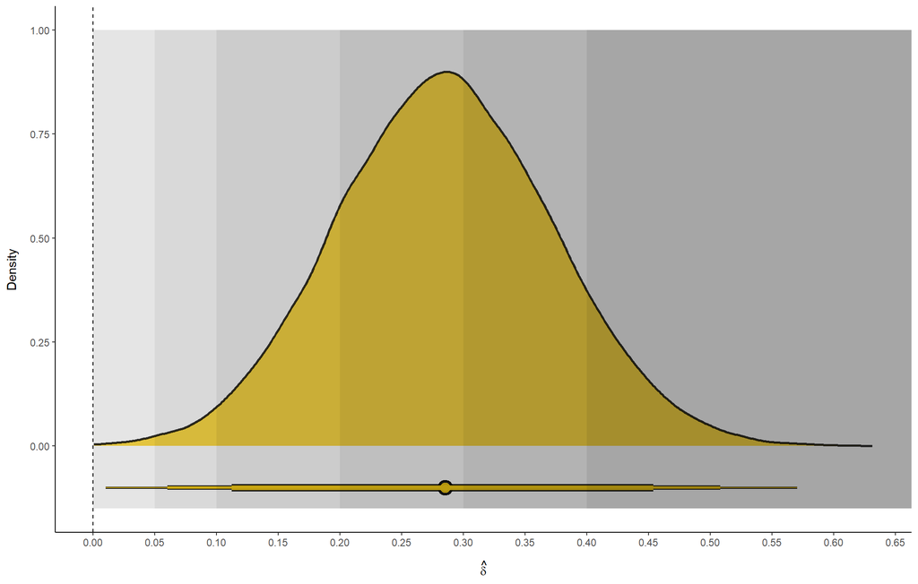

**NOTE**: Posterior distribution of the absolute time difference (in time second standard deviations) between measurements across group conditions. Effective samples = 13,051. The geometric below the distribution indicates the posterior mean (circle), the 95% HDI (thick bar), 99% HDI (thin bar), and 99.9% HDI (line). The dashed black line indicates a time difference of zero, while the increasingly shaded gray areas, from left to right, correspond to a ‘tiny’ ($\hat{\delta}$ < .05), ‘very small’ (.05 ≤ $\hat{\delta}$ < .1), ‘small’ (.1 ≤ $\hat{\delta}$ < .2), ‘medium’ (.2 ≤ $\hat{\delta}$ < .3), ‘large’ (.3 ≤ $\hat{\delta}$ < .4), and ‘very large’ (.4 ≤ $\hat{\delta}$), standardized differences (Funder and Ozer 2019).

The results reveal that the *a priori* expectation of a some time difference in generating and measuring the counterfactual outcomes across the control (“Lazy Recipient) and treatment (”Unlucky Recipient”) groups has been updated by the data resulting in a estimated average absolute time difference in time second standard deviations of .285 (SD = .087; 95% HDI[.118; .460]), which can be most credibly (40.58%) interpreted as a ‘medium’ sized difference (Funder and Ozer 2019). In an unstandardized format, this can be more easily interpreted as an absolute difference of .15 seconds in the measurement time across groups.

Table 4.8: Time Difference Between Measured Group Conditions

| $\hat{\theta}$ | $Parameter$ | $Estimate$ | $p_d$ | $p$ | $BF_{ln}$ | $ESS$ | $MCSE$ | $\hat{R}$ | $Prior$ |
| --- | --- | --- | --- | --- | --- | --- | --- | --- | --- |
| $\hat{\delta}$ | Mean | .285*** (.087) [.118; .460] | 1 | 0 | 2.559 (.525) | 13,051 | 0.001 | 1 | $T_3$(0.25, 0.25) |

**NOTE**: Bayesian Generalized (Gaussian) Linear Model, estimated using Bayes MCMC with NUTS. Posterior means (in seconds) with standard deviations in parentheses and 95% HDI in brackets. n = 100. $p_d$ = Probability of direction. $p$ = Probability of at least as extreme a sample estimate if assuming no difference in the population, #p ≤ .1, *p ≤ .05, *p ≤ .01, *p ≤ .001. $BF_{ln}$ = Natural-logarithm-scaled posterior odds. ESS = Effective sample size, ‘Sufficient’ if ≥ 1,000, otherwise ‘Insufficient’ (Bürkner 2017). $\hat{R}$ = Rubin-Gelman Convergence metric, ‘Excellent’ if < 1.01 (Vehtari et al. 2021), ‘Acceptable’ if < 1.1 (Gelman and Rubin 1992), otherwise ‘Unacceptable’. $T_3$ = Student t distribution with 3 degrees of freedom, all validated as ‘Uninformative’ relative to data (Makowski et al. 2019a). $PP_P$ (Gelman et al. 1996) = 0.023. $R_{loo}^2$ (Gelman et al. 2019) = -.009 (SD = .021; 95% HDI[-.049; .017]). RMSE ($\hat{\varsigma}$) = .953 (SD = .035; 95% HDI[.884; 1.000]; ESS = 14,707; MCSE = 0; $\hat{R}$ = 1; Prior = $T_3$(1, 0.295)). Synthetic data generated by OpenAI’s (2024a) gpt-4o-mini model based on vignettes and questions by (Aarøe and Petersen 2014) and data by the IPUMS (Ruggles et al. 2024) and ANES (2021).

As such, in this demonstration, there is some difference in the time of generating and measuring the counterfactual outcomes, which means that the estimated ITEs may be biased and confounded by time difference. However, it can be argued that the raw absolute time difference of merely .15 seconds is unlikely to cause substantial differences in the potential outcomes, which does lend some credence to the results, though this does not equate with the results being unbiased. With regards to the implementation of the ‘parallel worlds’-estimation procedure implemented here, the time difference is assessed to have a probability of 0% chance of happening if assuming the difference occurred by chance, making the difference statistically discernible from zero at conventional levels ($p ≤ .05$). This is corroborated by a posterior log-odds of 2.559 (SD = .525), which, following Raftery (1995), can be interpreted as ‘positive evidence in favour of’ the hypothesis that this implementation of ‘parallel worlds’-estimation will generally fails to ensure that counterfactual outcomes are generated simultaneously. Accordingly, the simultaneity assumption can be proven as testable, and it would seem that further work is needed to create implementations that do *not* produce results that violate the simultaneity assumption and thus risk time confounding results.

## 4.4 Bayesian Inference

To replicate the analyses across Aarøe and Petersen (2014), Mummolo and Peterson (2019), and Kane et al. (2023), the model used for statistical inference solely includes an intercept and coefficient for the difference between the control (“Lazy Recipient”) and treatment (“Unlucky Recipient”) manipulation conditions. Contrary to the original study, Bayesian inference is used, which can generally be considered superior in terms of interpretation and inference (Cohen 1994: 998-999; Pawitan 2001: 13; Clayton 2021; Gelman et al. 2021; Kruschke and Liddell 2018; McElreath 2019). A caveat of the SCT is that the data is to be transformed into a ‘long format’ to take advantage of the two counterfactual outcome observations for each synthetic respondent. This, however, creates a respondent-clustered structure in the data, which would violate the *iid* assumption, because observations in this format would not be independent. This can be accounted for with a hierarchical/multilevel model (Gelman and Hill 2007; Yarkoni 2020) that specifies a fixed and respondent-varying intercepts. Also, just like Aarøe and Petersen (2014), the measured welfare support outcome is *normalized*, or *min-maxed* (i.e., rescaled 0-1), to ease interpretation and comparability. Using notation similar to Nalborczyk et al. (2019), the specified multilevel model is provided in table 4.9.

Table 4.9: Modeled Relationship between Social Deservingness & Welfare Support

| $Y_i \: \overset{\mathrm{iid}}{\sim} \: \mathcal{N}(\mu_i, \sigma)$ | 1.1 |
| --- | --- |
| $\mu_i = \alpha \: + \: \beta_G \: \cdot \: G_i \: + \: \alpha_{i[id]}$ | 1.2 |
| $\beta_G \: \sim \: \mathcal{T}_3(0, \: .25)$ | 1.3 |
| $\alpha_{i[id]} \: \sim \: \mathcal{T}_3(\alpha, \: \sigma_{id})$ | 1.4 |
| $\alpha \: \sim \: \mathcal{T}_3(.362, \: .434)$ | 1.5 |
| $\sigma_{id} \: \sim \: \mathcal{T}_3^+(0, \: .25)$ | 1.6 |
| $\sigma \: \sim \: \mathcal{T}_3^+(.434, \: .132)$ | 1.7 |

**NOTE**: Multilevel Bayesian Generalized (Gaussian) Linear Model with respondent ID-varying intercepts. 1.1 is the likelihood-function, which specifies that the observations of the outcome variable $Y$ (i.e., welfare support) are assumed to be identically and independently (i.e., *iid*) distributed as a normal (Gaussian) distribution, with the mean and standard deviation parameter being the desired estimands. 1.2 is the *affine* function (Boyd and Vandenberghe 2018) of the mean parameter, which consists of a fixed (i.e., US-level) intercept, a fixed coefficient indicating the effect of group assignment (i.e., the social deservingness of the vignette welfare recipient), and random (i.e., respondent-level) varying intercepts. 1.3 is the prior of the group assignment coefficient, specified as a *Student t* distribution, with a 3 *degrees of freedom* (*df*) parameter, a mean of 0, and standard deviation of .25. 1.4 is the prior for the respondent-level varying intercepts, Student t distributed, with a *df* of 3, the mean being the US-level intercept, and an unknown standard deviation parameter. 1.5 is the intercept prior or the hyper prior for the mean parameter of the respondent-varying intercepts, being Student t distributed, *df* of 3, mean of .362, and a standard deviation of .434. 1.6 is the hyper prior for the standard deviation parameter of the respondent-varying intercepts, being distributed as a half-Student t, with a *df* of 3, mean of 0, and standard deviation of .25. 1.7 is the prior for the residual standard deviation of the outcome (RMSE), specified as a half-Student t distribution, with a *df* of 3, mean of .434, and standard deviation of .132.

The model assumes that the outcome distribution (i.e., welfare support) is identically and independently (*iid*), normal (Gaussian) distributed, with its mean and standard deviation being the estimands. The mean is modeled as an *affine* function (Boyd and Vandenberghe 2018), consisting of a fixed (global) intercept, a coefficient indicating the effect of seeing an ‘Unlucky’ compared to a ‘Lazy’ welfare recipient, and respondent-varying intercepts. Since the purpose is to compare the results to Aarøe and Petersen (2014) to validate the SCF’s generalizability, the priors do not incorporate information from Aarøe and Petersen (2014) but instead are specified as ‘weakly informative’, with mean and standard deviation parameters similar to those specified when testing the simultaneity assumption (table 4.7), though this model includes a hyper prior for the respondent-varying intercepts, as well as priors for its mean and standard deviation parameter that *a priori* expect little to no respondent-variability.

With this model specified, data is then formatted in a way to ease interpretation of the output. This means that the manipulations conditions are recoded so that the coefficient will indicate the effect of an increasing level of ‘social deservingness’ on the welfare support of the synthetic respondent. As such, it is *a priori* expected that increasing social deservingness increases welfare support, which will be supported by the coefficient being (1) non-negative, as indicated by a *probability of direction* ($p_d$, Makowski et al. 2019b) equal to or greater than 95% (i.e., $p_d ≥ .95$); (2) *statistically discernible* from zero, given by a *p*-value (Arbuthnot 1710; Pearson 1900) equal to or less than an $\alpha$ of .05 (i.e., $p ≤ .05$, Fisher 1970); and (3) that the *relative evidence* in the form of the *posterior log-odds* (a *Bayes factor* variant, Kass and Raftery 1995) indicates that the (alternative) hypothesis of a relationship between social deservingness and welfare is more probable than the (null) hypothesis of no such relationship (i.e., $BF_{ln} > 0$). Note that the original sample size of 100 in this long-format data provides an effective sample size of 200, since each synthetic respondent is observed two times, one for each counterfactual outcome. With these considerations in mind, an analysis of the results can be conducted.

# 5 Analyses

## 5.1 Confirmatory Analysis

To examine the theorized relationship between social deservingness and welfare support, the specified statistical model (see table 4.9) is fitted to the data. Similar to testing the simultaneity assumption, this procedures uses NUTS Hamiltonian MCMC (Hoffman and Gelman 2014) implemented in `brms` (Bürkner 2017, 2018), using 7 independent sampling chains, with 2,000 warmup samples per chain, followed by a total of 40,000 post-warmup samples. Results are provided graphically and metrically, with the estimated welfare support across groups being illustrated in figure 5.1, the size of the group difference in figure 5.2, and summary statistics in table 5.1. Inspecting these reveal that chain convergence was ‘excellent’ ($\hat{R}$ < 1.01, Gelman and Rubin 1992; Vehtari et al. 2021), with a ‘sufficient’ effective sample size (ESS > 1,000, Bürkner 2017), almost no sampling uncertainty (MCSE < .000, Kruschke 2014), and priors were validated as ‘uninformative’ relative to the data (Makowski et al. 2019a). However, the *posterior predictive p-value* ($PP_P$, Gelman et al. 1996) of 0.999 indicates a relatively low model fit, as the model tends to make exaggerated estimates of welfare support, possibly due to the low sample size. This is somewhat countered, though, by the Bayesian *loo*-adjusted $R^2$ (Gelman et al. 2019) of .696 (SD = .034; 95% HDI[.627; .759]), indicating that the model’s estimated out-of-sample predictive power can be interpreted as ‘substantial’ (Cohen 1988), revealing a relatively high fit. As such, focus can now be directed to the parameters of the model.

Figure 5.1: Group Differences in Welfare Support

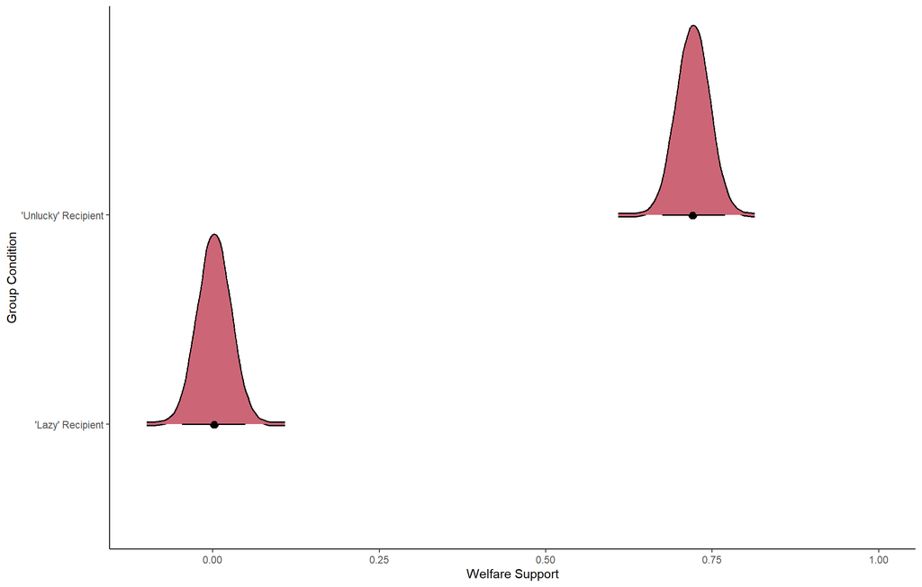

**NOTE**: Posterior distributions of the normalized welfare support across group conditions. $n$ = 200; $n_{ID}$ = 100. The geometric below the distributions indicate the posterior mean (circle) and the 95% HDI. Synthetic data generated by OpenAI’s (2024a) gpt-4o-mini model based on vignettes and questions created by (Aarøe and Petersen 2014) and data by the IPUMS (Ruggles et al. 2024) and ANES (2021).

**Does Social Deservingness Increase Welfare Support?** Evidently yes, since the average treatment effect (ATE) is credibly (95%) non-negative and non-zero, and the relative evidence provides ‘very strong evidence in favour of’ the relationship between social deservingness and welfare support. This is indicated by the normalized ‘social deservingness’-coefficient of .719 (SD = .033; 95% HDI[.653; .784]), which has an estimated 100% probability of being non-negative, and the relative size of this estimate has a probability of 0% of occurring by chance, assuming no effect, meaning it can be considered statistically discernibly different from zero ($p ≤ .05$. This is consistent with the theorized relationship and is further corroborated by a posterior log-odds of 59.929 (SD = .013), which, following Raftery (1995), can be interpreted as ‘very strong evidence in favour of’ the relationship between social deservingness and welfare support.

Figure 5.2: Relationship Between Social Deservingness & Welfare Support

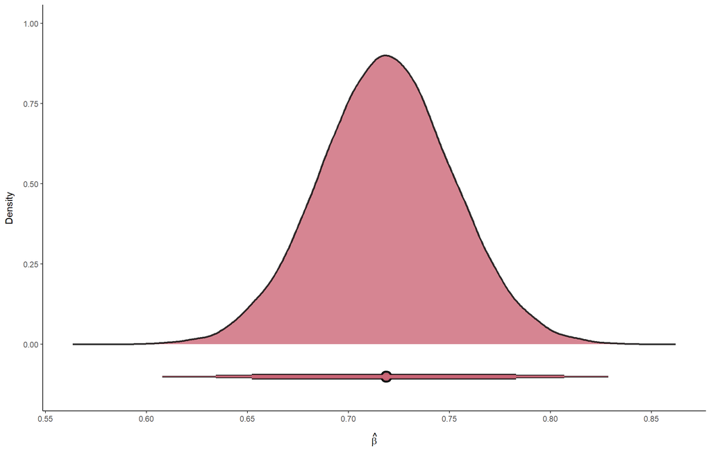

**NOTE**: Posterior distribution of the normalized coefficient of social deservingness on welfare support. Effective samples = 62,114. The geometric below the distribution indicates the posterior mean (circle), the 95% HDI (thick bar), 99% HDI (thin bar), and 99.9% HDI (line). Synthetic data generated by OpenAI’s (2024a) gpt-4o-mini model based on vignettes and questions created by (Aarøe and Petersen 2014) and data by the IPUMS (Ruggles et al. 2024) and ANES (2021).

The estimated effect of social deservingness on welfare support can, following King et al. (2000), be interpreted as the following: All else equal (*ceteris paribus*), an individual’s support for tightening the requirements for welfare eligibility is on average 71.87 *percentage points (pp)* lower, plus or minus 3.32 *pp*, and with 95% credibility between 65.32 and 78.41 *pp*, when seeing an ‘unlucky’ welfare recipient (i.e., high in social deservingness) compared to seeing a ‘lazy’ welfare recipient (i.e., low in social deservingness).

Table 5.1: Relationship Between Social Deservingness & Welfare Support

| $\hat{\theta}$ | $Parameter$ | $Estimate$ | $p_d$ | $p$ | $BF_{ln}$ | $ESS$ | $MCSE$ | $\hat{R}$ | $Prior$ |
| --- | --- | --- | --- | --- | --- | --- | --- | --- | --- |
| $\hat{\beta}$ | Deservingness | .719*** (.033) [.653; .784] | 1.00 | 0.000 | 59.929 (.013) | 62,114 | 0 | 1 | $T_3$(0, 0.25) |
| $\hat{\alpha}$ | Intercept | .002 (.024) [-.045; .050] | 0.54 | 0.921 | -3.416 (.012) | 58,395 | 0 | 1 | $T_3$(0.362, 0.434) |

**NOTE**: Multilevel Bayesian Generalized (Gaussian) Linear Model, estimated using Bayes MCMC with NUTS, with respondent ID-varying intercepts. Normalized coefficient posterior means with standard deviations in parentheses and 95% HDI in brackets. $n$ = 200; $n_{ID}$ = 100. $p_d$ = Probability of direction. $p$ = Probability of at least as extreme a sample estimate if assuming no difference in the population, #p ≤ .1, *p ≤ .05, *p ≤ .01, *p ≤ .001. $BF_{ln}$ = Natural-logarithm-scaled Bayes factor/posterior odds. ESS = Effective sample size, ‘Sufficient’ if ≥ 1,000, otherwise ‘Insufficient’ (Bürkner 2017). $\hat{R}$ = Rubin-Gelman Convergence metric, ‘Excellent’ if < 1.01 (Vehtari et al. 2021), ‘Acceptable’ if < 1.1 (Gelman and Rubin 1992), otherwise ‘Unacceptable’. $T_3$ = Student t distribution with 3 degrees of freedom, all validated as ‘Uninformative’ relative to data (Makowski et al. 2019a). $PP_P$ (Gelman et al. 1996) = 0.999. $R_{loo}^2$ (Gelman et al. 2019) = .696 (SD = .034; 95% HDI[.627; .759]). RMSE ($\hat{\sigma}$) = .235 (SD = .013; 95% HDI[.210; .261]; ESS = 28,124; MCSE = 0; $\hat{R}$ = 1; Prior = $T_3$(0.434, 0.132)). Synthetic data generated by OpenAI’s (2024a) gpt-4o-mini model based on vignettes and questions created by (Aarøe and Petersen 2014) and data by the IPUMS (Ruggles et al. 2024) and ANES (2021).

**Do the results replicate the meta-analysis?** Arguably, yes and no. The positive estimated effect of social deservingness on welfare support, as well as the relative evidence that favors the hypothesized relationship, does replicate the overall result and conclusion by Aarøe and Petersen (2014), Mummolo and Peterson (2019), and Kane et al. (2023), thus strengthening the scientific evidence for a relationship between social deservingness and welfare support. However, the difference in estimated effect in this study of .719 (SD = .033; 95% HDI[.653; .784]) and the meta-analytic estimate of .32 (SD = .07; 95% HDI[.16; .48]) can be considered quite substantial. This relevant discrepancy could be attributable to relying on synthetic respondents, but it could also be attributable to a type M error (Gelman and Carlin 2014) and differences in sample compositions, such as the overrepresentation of republicans/conservatives in this study, where social deservingness would expectedly have a larger effect. This can be sought accounted for by analyzing the heterogeneity of the estimated effect across preferred political party and political ideology.

## 5.2 Heterogeneity Analysis

A heterogeneity analysis can be conducted to test the aforementioned expectation that the effect of social deservingness on welfare support interacts with preferred political party and political ideology. If this is the case, the sample-population imbalance on these characteristics could explain the discrepancy between the results in the main analysis and the meta-analysis results by Aarøe and Petersen (2014), Mummolo and Peterson (2019), and Kane et al. (2023). This is first tested by specifying a Frequentist model equivalent to the one in the main analysis, that besides dropping the prior specifications, includes an interaction term between the manipulation condition and preferred political party. The second model is the same, except for the interaction term involving political ideology instead. Fitting the models to data, results reveal that the interaction term in both models are statistically discernible from zero ($p ≤ .05$). Since the same conclusion is derived from both models, to remain concise, only the results from the political party interaction-model is shown here, provided metrically in the table below.

**Relationship between Political Party and the Effect of Social Deservingness & Welfare Support**

|  | *Dependent variable:* |
| --- | --- |
|  | Welfare Support |
| Social Deservingness | .341*** (.311;.372) |
| Republican Party | -0.000 (-.028;.028) |
| Social Deservingness x Republican Party | .647*** (.607;.687) |
| Intercept | 0.000 (-.022;.022) |
| Observations | 200 |
| Log Likelihood | 232.000 |
| Akaike Inf. Crit. | -453.000 |
| Bayesian Inf. Crit. | -433.000 |
| *Note:* | p<0.05; p<0.01; p<0.001 |

As is evident by these results, the effect of social deservingness on welfare support among respondents that prefer the Democratic Party, the estimate effect is .34 (SE = .02; 95% CI[.31; .37]), while the effect for republicans is substantially higher. The effect among democrats is substantially closer to the meta-analytic estimate of .32 (SD = .07; 95% HDI[.16; .48]) from Aarøe and Petersen (2014), Mummolo and Peterson (2019), and Kane et al. (2023), and if this study has a slight overrepresentation of democrats similar to the population, the ATE estimated in the main analysis, would have been much more similar to the meta-analytic estimate. As such, the discrepancy is consistent with differences in sample composition, specifically the overrepresentation of republicans/conservatives, for whom the effect of social deservingness on welfare support if larger than democrats/liberals. This means that, when accounting for this sample-population imbalance, that this application of the Synthetic Causal Framework can be considered to have successfully replicated the relationship between social deservingness and welfare support. This indicates that the SCF can be considered not only a reliable approach to causal inference that guarantees a high internal validity, but a framework that produces results that can generalize to human populations. To wrap up these results, a cost analysis will summarize the resources used in this demonstration of the Synthetic Causal Framework.

## 5.3 Cost Analysis

The costs associated with generating the life-histories and the preceding analyses can be estimated using the token costs. Costs vary for input and output tokens, as well as across OpenAI’s (2024a) models, with the selected gpt-4o-mini being the cheapest at the time of writing, charging on average 0.375 $US per 1,000,000 input/output tokens used.

**Financial Costs**. In terms of financial costs, generating 100 life-histories and two counterfactual outcomes with the provided prompts and specified settings, the total cost is estimated to be .05 $US. This means that the expected financial cost per respondent is .00 (SD = .00) $US. Compared to studies that rely on human participants, this can be considered relatively cheap, especially considering the substantial gain in internal validity to relying on this procedure to generate synthetic respondents.

**Time Costs**. Another relevant cost for researchers to consider is time costs. Besides setting up the relatively easily adaptable code used in this study for implementing the synthetically controlled trial, as well as fitting the Bayesian models to the data, generating the life-histories and the outcomes for the ‘Lazy’ and ‘Unlucky’ welfare recipients took a total of 23.55 minutes. With 100 synthetic respondents, the expected time cost per respondent is 14.13 (SD = .00) seconds. Compared to human studies that may take weeks if not months to obtain a sizable sample, this can be considered a substantial reduction in the time taking to obtain survey responses. This means that researchers can save time by conducting a Synthetically Controlled Trial (SCT) compared to having to rely on human respondents.

This cost analysis thus reveals that the Synthetic Causal Framework (SCF), through is implementation as an SCT, can be considered less costly, both in terms of the financial and time resources needed to conduct a study. The SCT can thus save resources for researchers, and the bar needed to conduct a study with a high internal validity is substantially lowered, thus increasing the availability for researchers to make causal inferences across disciplines.

# 6 Discussion

Given the results produced by the implementation of a Synthetically Controlled Trial (SCT) in this study, a series of methodological concerns can be discussed. This includes possible implications for the internal validity, external validity, ecological validity, implementation, and costs of this current rendition of the Synthetic Causal Framework (SCF).

**Internal Validity.** The Synthetic Causal Framework serves to provide researchers with an alternative for drawing reliable causal inference. As formalized and demonstrated, the framework provides a sound theoretical approach for ensuring that estimates are solely attributable to researcher manipulation of the theorized cause. Since each individual is assigned all manipulation conditions, there is no confounding of results due to perfect balance between conditions. The SCF addresses time as a relevant confounder and posits ‘parallel worlds’-estimation as an approach to avoid this, though the current parallel processing implementation did not produce the necessary simultaneous generation and measurement of all counterfactual outcomes, allowing the ITEs and ATE to be confounded by time. This is possibly attributable to the systematic differences in prompt length, since the ‘Unlucky Welfare Recipient’ vignette was slightly longer than the ‘Lazy Welfare Recipient’ vignette, which could impact the time needed for the NLP-model to process the input. Nonetheless, by introducing the simultaneity assumption, and tests for this assumption, the SCF introduces new considerations of potential confounders, thus setting a higher bar for what reliable causal inference entails.

**External Validity.** In terms of external validity, the Synthetic Causal Framework arguably makes a trade-off between internal and external validity by relying on synthetic respondents rather than human respondents. This is a trade-off common to experimental designs, and while this may be a concern for some researchers, others have found no discernible impact on the external validity of results (Druckman 2015: 62). Some even argue for superior external validity of results (Samii 2016), at least compared to non-experimental designs, since efforts to isolate causal effects can introduce new biases (Wan et al. 2024) and reduce transparency in what population to infer results to (Aronow and Samii 2016). Nevertheless, the implemented SCT aims for an external validity similar to survey experiments by simulating human characteristics and generating life-histories to promote a more realistic NLP-driven behavior. This was corroborated by the ability to closely replicate the established relationship between social deservingness and welfare support. Despite this, it remains unlikely that synthetic respondents fully capture the nuanced (and sometimes idiosyncratic) behavior of human individuals. Similarly, it will take more studies to establish whether the SCF and its implementations can consistently produce results that generalize to human populations. Until then, generalizing synthetic results to human population should be considered with caution.

**Ecological Validity.** Similar to external validity, the ecological validity of Synthetic Causal Framework-based results heavily depend on the ability of the used NLP-models to realistically mimic human behavior. To ensure a high ecological validity, it is likely that more characteristics will need to be simulated to provide the NLP-model with the necessary context to properly infer the behavior of such a person in real life. Such characteristics could potentially include, for example, personality traits and other psychological characteristics that have a great bearing on human everyday behavior. It is also likely that the characteristics that are relevant to simulate will vary depending on the research question. For example, religious affiliation could be a relevant characteristic to simulate if investigating causes that impact whether individuals favor Israel or Palestine in the currently ongoing conflict. It is likely that the ecological validity varies between NLP-models, and given their constant improvement, future models could likely outperform the gpt-4o-mini model used here.

**Implementations & Costs.** The implementation of the Synthetic Causal Framework as a Synthetically Controlled Trial (SCT) served as an analogue to the popular Randomized Controlled Trial (RCT, Coover and Angell 1907; Peirce and Jastrow 1885; Woodworth and Thorndike 1901), which demonstrated how the framework could be implemented to draw reliable causal inference. This procedure could be considered relatively cheap in terms of both financial and time costs, making it an easily implementable and cheap alternative for researchers interested in causal inference. It should be noted that the SCF is not restricted to SCTs but could potentially be implemented in alternative ways depending on the research question and the phenomenon being studied. An implementation of the SCF need not mimic a survey setting, and synthetic human behavior could be studied in multiple ways. An example that draws on another causal methodology include the *Regression Discontinuity Design* (RDD, Skovron and Titiunik 2015; Thistlethwaite and Campbell 1960), popular in policy analyses, where synthetic respondents could be observed for a time period until they are exposed to some treatment that is theorized to impact an outcome of interest. Alternative implementations may affect financial costs, such as if more or lengthier prompts are needed, and the time costs will likely increase if more requests from the NLP-model are made. The adaptability of the SCF and the ongoing development of NLP-models, however, does provide researchers with the ability to develop their own implementations of the SCF that may become cheaper and more reliable over time.

Having discussed these concerns, the Synthetic Causal Framework provides researchers with a needed alternative to ensure the high internal validity necessary to draw reliable causal inference when a phenomenon of interest cannot be manipulated. These results could then be generalized to human populations, though some caution is warranted given the novelty of the framework. The SCF can be easily implemented, for example, as a Synthetically Controlled Trial, and is cheap in terms of financial and time costs. While concerns for the generalizability of SCF-based results to human populations remain warranted, advances in the implementation of the SCF and the ability of NLP-models to realistically mimic human individuals will likely increase over time.

# 7 Conclusion

This paper has introduced the *Synthetic Causal Framework* (SCF), a novel framework for drawing causal inference by generating respondents using an NLP-based synthesis of simulated and real human data. The primary purpose of the SCF is to solve the inability of researchers to reliably draw causal inference when the theorized cause cannot be manipulated, either by the researchers themselves, as in *Randomized Controlled Trials* (RCTs, Coover and Angell 1907; Peirce and Jastrow 1885; Woodworth and Thorndike 1901), or through natural processes, such as in *natural experiments* (Dunning 2008). The SCF solves this issue by simulating data and synthesizing it with real human data using Natural Language Processing (NLP) models, trained to mimic human behavior as expressed through language. In this NLP-based environment, researchers can vary manipulations and simultaneously observe all counterfactual outcomes resulting from these manipulations. With every respondent being in all manipulation conditions, the SCF ensures a perfect balance between the treatment and control groups, thus guaranteeing no confounding of results.

The SCF was formalized using the *Neyman-Rubin Potential Outcomes Framework* (Imbens and Rubin 2015), providing analytical expressions of its underlying logic and assumptions. A demonstration followed in the form of a *Synthetically Controlled Trial* (SCT) that sought to replicate the established relationship between social deservingness and welfare support. This demonstration showed how to simulate respondent characteristics proportional to the population of the United States, making results more representative of that population. It was then shown how to create prompts to generate life-histories for the simulated respondent, adding extra nuance to the simulated characteristics, which served to make the selected NLP-model, OpenAI’s (2024a) gpt-4o-mini, more capable of realistically imitating the behavior of a person with those traits. An implementation of ‘parallel worlds’-estimation was provided, which utilized parallel processing to generate and measure two counterfactual levels of welfare support from exposure to a ‘Lazy’ and ‘Unlucky’ welfare recipient vignette. The replication then proved perfect group balance in terms of the simulated characteristics and tested the simultaneity assumption, finding a modest time difference between groups, making results confoundable by time differences. A Bayesian mixed-effects statistical model was specified, producing results that following an adjustment for population-sample imbalance, closely replicated the human-based results of an effect of social deservingness on welfare support. As such, the SCF offers a novel alternative for researchers to reliably draw causal inference, with a currently promising generalizability to human populations. Future developments of the SCF are expected in future studies, which will expectedly further increase its scientific utility.

# 8 Declarations

**Author Contributions**

- Emil Meyer-Hansen conceived, conceptualized, and formalized the Synthetic Causal Framework (SCF) and Synthetically Controlled Trials (SCTs), implemented the demonstration, simulated and synthesized the data, conducted the analyses, and wrote this manuscript.

**Funding**

- Emil Meyer-Hansen received no funding to assist with this project.

**Conflicts of Interest**

- Emil Meyer-Hansen has no competing interests to declare that are relevant to the content of this project.

**Availability of Data & Materials**

- Data and materials are not made available in this preview version.

**Code availability**

- The computer code for the simulation is not made available in this preview version.

**Acknowledgements**

- This project was made possible by building on insights and contributions from numerous researchers across disciplines. While the author is indebted to an insurmountable number of researchers, a special gratitude, in no particular order, is extended to Jerzy Neyman, Ronald A. Fisher, Donald B. Rubin, Guido W. Imbens, Joshua Angrist, Jörn-Steffen Pischke, Judea Pearl, Susan Athey, Alberto Abadie, Aexis Diamond, Jens Hainmueller, Peter M. Aronow, and Cyrus Samii for their contributions to causal inference. For their contributions to statistics important for causal inference, a special gratitude is extended to Francis Galton, Karl Pearson, Egon Pearson, Bradley Efron, David R. Cox, Andrew Gelman, Aki Vehtari, Gary King, and Jennifer Hill. For their contributions to statistical software, which this project was heavily dependent on, a special gratitude is extended to the R Core Team, the Posit Team, Hadley Wickham, Iegor Rudnytskyi, Steve Weston, Paul-Christian Bürkner, Dominique Makowski, Mattan S. Ben-Shachar, Daniel Lüdecke, Benjamin Goodrich, and Jonah Gabry. For their contributions to the development of a high quality standard in science, a special gratitude is extended to Jacob Cohen, Gert Gigerenzer, Paul Meehl, Uri Simonsohn, Leif D. Nelson, Joseph Simmons, Richard McElreath, Tal Yarkoni, and Elizabeth A. Stuart. And for the development of the GPT models, which was vital to the implementation of the SCF in this project, a special gratitude is extended to OpenAI.

# 9 References

Aarøe, L., and Petersen, M. B. (2014), “Crowding out culture: Scandinavians and americans agree on social welfare in the face of deservingness cues,” *The Journal of Politics*, 76, 684–697. https://doi.org/10.1017/S002238161400019X.

Alister, M., Vickers-Jones, R., Sewell, D. K., and Ballard, T. (2021), “How do we choose our giants? Perceptions of replicability in psychological science,” *Advances in Methods and Practices in Psychological Science*, 4, 251524592110181. https://doi.org/10.1177/25152459211018199.

Allaire, J. J., Xie, Y., Dervieux, C., McPherson, J., Luraschi, J., Ushey, K., Atkins, A., Wickham, H., Cheng, J., Chang, W., and Iannone, R. (2024), *[Rmarkdown: Dynamic documents for r](https://github.com/rstudio/rmarkdown)*.

Altman, D. G., and Bland, J. M. (1994), “Diagnostic tests 2: Predictive values,” *BMJ*, 309, 102. https://doi.org/10.1136/bmj.309.6947.102.

ANES (2021), “[ANES 2020 time series study full release [dataset and documentation]](https://electionstudies.org/data-center/2020-time-series-study/),” American National Election Studies; ANES.

Angrist, J. D., Imbens, G. W., and Rubin, D. B. (1996), “Identification of causal effects using instrumental variables,” *Journal of the American Statistical Association*, 91, 444–455. https://doi.org/10.1080/01621459.1996.10476902.

Arbuthnot, J. (1710), “An argument for divine providence, taken from the constant regularity observed in the births of both sexes,” *Philosophical Transactions of the Royal Society of London*, 27, 186–190. https://doi.org/10.1098/rstl.1710.0011.

Aronow, P. M., and Samii, C. (2016), “Does regression produce representative estimates of causal effects?” *American Journal of Political Science*, 60, 250–267. https://doi.org/10.1111/ajps.12185.

Aronow, P. M., and Samii, C. (2017), “Estimating average causal effects under general interference, with application to a social network experiment,” *The Annals Of Applied Statistics*, 11, 1912–1947. https://doi.org/10.1214/16-AOAS1005.

Barrett, M. (2024), *[Ggdag: Analyze and create elegant directed acyclic graphs](https://CRAN.R-project.org/package=ggdag)*.

Bates, D., Mächler, M., Bolker, B., and Walker, S. (2015), “Fitting linear mixed-effects models using lme4,” *Journal of Statistical Software*, 67, 1–48. https://doi.org/10.18637/jss.v067.i01.

Bayes, T., and Price, R. (1763), “An essay towards solving a problem in the doctrine of chance. By the late rev. Mr. Bayes, communicated by mr. Price, in a letter to john canton, a.m.f.r.s.” *Philosophical Transactions of the Royal Society of London*, 53, 370–417. https://doi.org/10.1098/rstl.1763.0053.

Ben-Shachar, M. S., Lüdecke, D., and Makowski, D. (2020), “effectsize: Estimation of effect size indices and standardized parameters,” *Journal of Open Source Software*, The Open Journal, 5, 2815. https://doi.org/10.21105/joss.02815.

Berkson, J. (1944), “Application of the logistic function to bio-assay,” *Journal of the American Statistical Association*, 39, 357–365. https://doi.org/10.1080/01621459.1944.10500699.

Boyd, S. P., and Vandenberghe, L. (2018), *Introduction to applied linear algebra: Vectors, matrices, and least squares*, Cambridge University Press.

Breiman, L. (2001), “Random forests,” *Machine Learning*, 45, 5–32. https://doi.org/10.1023/A:1010933404324.

Bürkner, P.-C. (2017), “brms: An R package for Bayesian multilevel models using Stan,” *Journal of Statistical Software*, 80, 1–28. https://doi.org/10.18637/jss.v080.i01.

Bürkner, P.-C. (2018), “Advanced Bayesian multilevel modeling with the R package brms,” *The R Journal*, 10, 395–411. https://doi.org/10.32614/RJ-2018-017.

Christensen, G., Freese, J., and Miguel, E. (2019), *Transparent and reproducible social science research: How to do open science*, Oakland, California: University of California Press.

Clayton, A. (2021), *Bernoulli’s fallacy: Statistical illogic and the crisis of modern science*, Columbia University.

Cohen, J. (1960), “A coefficient of agreement for nominal scales,” *Educational and Psychological Measurement*, 20, 37–46. https://doi.org/10.1177/001316446002000104.

Cohen, J. (1988), *Statistical power analysis for the behavioral sciences*, Lawrence Erlbaum Associates.

Cohen, J. (1991), “A power primer,” *Psychological Bulletin*, 112, 155–159. https://doi.org/10.1037/0033-2909.112.1.155.

Cohen, J. (1994), “The earth is round (p < .05),” *The American Psychologist*, 49, 997–1003. https://doi.org/10.1037/0003-066X.49.12.997.

Comtois, D. (2022), *[Summarytools: Tools to quickly and neatly summarize data](https://CRAN.R-project.org/package=summarytools)*.

Coover, J. E., and Angell, F. (1907), “General practice effect of special exercise,” *The American Journal of Psychology*, 18, 328–340. https://doi.org/10.2307/1412596.

Cox, D. R. (1958), “The regression analysis of binary sequences (with discussion),” *The Journal of the Royal Statistical Society, Series B (Statistical Methodology)*, 20, 215–242. https://doi.org/10.1111/j.2517-6161.1958.tb00292.x.

Druckman, J. N. (2015), *Experimental thinking: A primer on social science experiments*, Cambridge: Cambridge University Press. https://doi.org/10.1017/9781108991353.

Duane, S., Kennedy, A. D., Pendleton, B. J., and Roweth, D. (1987), “Hybrid monte carlo,” *Physics letters. B*, 195, 216–222. https://doi.org/10.1016/0370-2693(87)91197-X.

Dunning, T. (2008), “Improving causal inference: Strengths and limitations of natural experiments,” *Political Research Quarterly*, 61, 282–293. https://doi.org/10.1177/1065912907306470.

Eddelbuettel, D. (2017), *[Random: True random numbers using RANDOM.ORG](https://CRAN.R-project.org/package=random)*.

Edwards, A. (1953), “[The relationship between the judged desirability of a trait and the probability that the trait will be endorsed](https://10.1037/h0058073),” *Journal of Applied Psychology*, 37, 90–93.

Efron, B. (1979), “Bootstrap methods: Another look at the jackknife,” *The Annals of Statistics*, 7, 1–26. https://doi.org/10.1214/aos/1176344552.

Efron, B. (2003), “Second thoughts on the bootstrap,” *Statistical Science*, 18, 135–140. https://doi.org/10.1214/ss/1063994968.

Eysenck, H. J. (1995), “[Meta-analysis or best-evidence synthesis?](https://10.1111/j.1365-2753.1995.tb00005.x)” *Journal of Evaluation in Clinical Practice*, 1, 29–36.

Fisher, R. A. (1970), *Statistical methods for research workers*, Hafner Publishing Company.

Fleiss, J. L. (1971), “Measuring nominal scale agreement among many raters,” *Psychological Bulletin*, 76, 378–382. https://doi.org/10.1037/h0031619.

França, A. R. M., Rocha, E., Bastos, L. S. L., Bozza, F. A., Kurtz, P., Maccariello, E., Silva, L. E., Roberto, J., and Salluh, J. I. F. (2024), “Development and validation of a machine learning model to predict the use of renal replacement therapy in 14,374 patients with COVID-19,” *Journal of Critical Care*, 80, 154480. https://doi.org/10.1016/j.jcrc.2023.154480.

Funder, D. C., and Ozer, D. J. (2019), “Evaluating effect size in psychological research: Sense and nonsense,” *Advances in Methods and Practices in Psychological Science*, 2, 155–168. https://doi.org/10.1177/2515245919847202.

Gabry, J., Simpson, D., Vehtari, A., Betancourt, M., and Gelman, A. (2019), “Visualization in bayesian workflow,” *The Journal of the Royal Statistical Society, Series A (Statistics in Society)*, 182, 389–402. https://doi.org/10.1111/rssa.12378.

Gaenssler, P., and Stute, W. (1979), “Empirical processes: A survey of results for independent and identically distributed random variables,” *The Annals of Probability*, 7, 193–243. https://doi.org/10.1214/aop/1176995085.

Gaines, B. J., Kuklinski, J. H., and Quirk, P. J. (2006), “[The logic of the survey experiment reexamined](https://10.1093/pan/mpl008),” *Political Analysis*, 15, 1–20.

Gelman, A., and Carlin, J. B. (2014), “Beyond power calculations: Assessing type s (sign) and type m (magnitude) errors,” *Perspectives on Psychological Science*, 9, 641–651. https://doi.org/10.1177/1745691614551642.

Gelman, A., Carlin, J. B., Stern, H. S., Dunson, D. B., Vehtari, A., and Rubin, D. B. (2014), *Bayesian data analysis*, Chapman & Hall/CRC Press.

Gelman, A., Goodrich, B., Gabry, J., and Vehtari, A. (2019), “R-squared for bayesian regression models,” *The American Statistician*, 73, 307–309. https://doi.org/10.1080/00031305.2018.1549100.

Gelman, A., and Hill, J. (2007), *Data analysis using regression and multilevel/hierarchical models*, Cambridge: Cambridge University Press.

Gelman, A., Hill, J., and Vehtari, A. (2021), *Regression and other stories*, Cambridge University Press. https://doi.org/10.1017/9781139161879.

Gelman, A., and Little, T. C. (1997), “Poststratification into many categories using hierarchical logistic regression,” *Survey Methodology*, 23, 127–135.

Gelman, A., Meng, X.-L., and Stern, H. (1996), “Posterior predictive assessment of model fitness via realized discrepancies,” *Statistica Sinica*, 6, 733–760.

Gelman, A., and Rubin, D. B. (1992), “Inference from iterative simulation using multiple sequences,” *Statistical Science*, 7, 457–472. https://doi.org/10.1214/ss/1177011136.

Glass, G. V. (1976), “[Primary, secondary, and meta-analysis of research](https://10.3102/0013189X005010003),” *Educational Researcher*, 5, 3–8.

Göb, R., McCollin, C., and Ramalhoto, M. F. (2007), “Ordinal methodology in the analysis of likert scales,” *Quality & Quantity*, 41, 601–626. https://doi.org/10.1007/s11135-007-9089-z.

Gosset, W. S. (1908), “The probable error of a mean,” *Biometrika*, 6, 1–25. https://doi.org/10.2307/2331554.

Gottlieb, A., and Almasi, G. S. (1989), *Highly parallel computing*, Redwood City, California: Benjamin/Cummings.

Gruber, J. (2014), *[The markdown file extension](https://daringfireball.net/linked/2014/01/08/markdown-extension)*, The Daring Fireball Company, LLC.

Hartman, E., and Hidalgo, F. D. (2018), “An equivalence approach to balance and placebo tests,” *American Journal of Political Science*, 62, 1000–1013. https://doi.org/10.1111/ajps.12387.

Hastie, T. J., and Tibshirani, R. J. (1990), *Generalized additive models*, Chapman & Hall/CRC.

Helmert, F. R. (1876a), “Über die wahrscheinlichkeit der potenzsummen der beobachtungsfehler und uber einige damit in zusammenhang stehende fragen,” *Zeitschrift für Angewandte Mathematik und Physik*, 21, 192–218.

Helmert, F. R. (1876b), “Die genauigkeit der formel von peters zur berechnung des wahrscheinlichen beobachtungsfehlers directer beobachtungen gleicher genauigkeit,” *Astronomische Nachrichten*, 88, 113–132.

Helmert, F. R. (1875), “Über die berechnung des wahrscheinlichen fehlers aus einer endlichen anzahl wahrer beobachtungsfehler,” *Zeitschrift für Angewandte Mathematik und Physik*, 20, 300–303.

Ho, T. K. (1995), “Random decision forests,” *Proceedings of the 3rd International Conference on Document Analysis and Recognition*, Montreal, QC: Institute of Electrical; Electronics Engineers, 278–282. https://doi.org/10.1109/ICDAR.1995.598994.

Hoffman, M. D., and Gelman, A. (2014), “The no-u-turn sampler: Adaptively setting path lengths in hamiltonian monte carlo,” *Journal of Machine Learning Research*, 15, 1593–1623. https://doi.org/10.48550/arxiv.1111.4246.

Holland, P. W. (1986), “Statistics and causal inference,” *Journal of the American Statistical Association*, 81, 945–960. https://doi.org/10.1080/01621459.1986.10478354.

Hughes, J. (2022), “Sklar’s omega: A gaussian copula-based framework for assessing agreement,” *Statistics and computing*, 32, 46. https://doi.org/10.1007/s11222-022-10105-2.

Hurault, G. (2021), *[HuraultMisc: Guillem hurault functions’ library](https://CRAN.R-project.org/package=HuraultMisc)*.

Imbens, G. W., and Rubin, D. B. (2015), *Causal inference for statistics, social, and biomedical sciences: An introduction*, Cambridge: Cambridge University Press. https://doi.org/10.1017/CBO9781139025751.

Jung, L. (2024), *[Scrutiny: Error detection in science](https://CRAN.R-project.org/package=scrutiny)*.

Kalton, G., and Kasprzyk, D. (1982), “Imputing for missing survey responses,” *Proceedings of the Section on Survey Research Methods*, 22, 22–31.

Kane, J. V., Velez, Y. R., and Barabas, J. (2023), “Analyze the attentive and bypass bias: Mock vignette checks in survey experiments,” *Political Science Research and Methods*, 11, 293–310. https://doi.org/10.1017/psrm.2023.3.

Kass, R. E., and Raftery, A. E. (1995), “Bayes factors,” *Journal of the American Statistical Association*, 90, 773–795. https://doi.org/10.1080/01621459.1995.10476572.

Kassambara, A. (2023), *[Ggpubr: ’ggplot2’ based publication ready plots](https://CRAN.R-project.org/package=ggpubr)*.

Kay, M. (2023), *tidybayes: Tidy data and geoms for Bayesian models*. https://doi.org/10.5281/zenodo.1308151.

Kendall, M. G. (1938), “A new measure of rank correlation,” *Biometrika*, 30, 81–89. https://doi.org/10.1093/biomet/30.1-2.81.

King, G., Honaker, J., Joseph, A., and Scheve, K. (2001), “Analyzing incomplete political science data: An alternative algorithm for multiple imputation,” *American Political Science Review*, 95, 49–69. https://doi.org/10.1017/S0003055401000235.

King, G., Tomz, M., and Wittenberg, J. (2000), “Making the most of statistical analyses: Improving interpretation and presentation,” *American Journal of Political Science*, 44, 347–361. https://doi.org/10.2307/2669316.

Kozlowski, A. C., Taddy, M., and Evans, J. A. (2019), “The geometry of culture: Analyzing the meanings of class through word embeddings,” *American Sociological Review*, 84, 905–949. https://doi.org/10.1177/0003122419877135.

Krippendorff, K. (2018), *Content analysis: An introduction to its methodology*, Los Angeles: Sage.

Krotov, V., and Tennyson, M. (2018), “Research note: Scraping financial data from the web using the r language,” *Journal of Emerging Technologies in Accounting*, 15, 169–181. https://doi.org/10.2308/jeta-52063.

Krumpal, I. (2013), “[Determinants of social desirability bias in sensitive surveys: A literature review](https://10.1007/s11135-011-9640-9),” *Quality & Quantity*, 47, 2025–2047.

Kruschke, J. K. (2014), *Doing bayesian data analysis: A tutorial with r, JAGS, and stan*, Academic Press.

Kruschke, J. K., and Liddell, T. M. (2018), “The bayesian new statistics: Hypothesis testing, estimation, meta-analysis, and power analysis from a bayesian perspective,” *Psychonomic Bulletin and Review*, 25, 178–206. https://doi.org/10.3758/s13423-016-1221-4.

Lamport, L. (1986), *LATEX: A document preparation system*, Addison-Wesley Pub. Co.

Lantz, B. (2013), “Equidistance of likert-type scales and validation of inferential methods using experiments and simulations,” *The Electronic Journal of Business Research Methods*, 11, 16–28.

Laplace, P. S. (2009[1814]), *Essai philosophique sur les probabilités*, Cambridge: Cambridge University Press.

Lenz, G. S., and Sahn, A. (2021), “Achieving statistical significance with covariates and without transparency,” *Political Analysis*, 29, 356–369. https://doi.org/10.1017/pan.2020.31.

Liaw, A., and Wiener, M. (2002), “[Classification and regression by randomForest](https://CRAN.R-project.org/doc/Rnews/),” *R News*, 2, 18–22.

Likert, R. (1932), “A technique for the measurement of attitudes,” *Archives of Psychology*, 22, 55.

Lüroth, J. (1876), “Vergleichung von zwei werten des wahrscheinlichen fehlers,” *Astronomische Nachrichten*, 87, 209–220. https://doi.org/10.1002/asna.18760871402.

Maier, M., Bartos, F., Stanley, T. D., Shanks, D. R., Harris, A. J. L., and Wagenmakers, E.-J. (2022), “[No evidence for nudging after adjusting for publication bias](https://10.1073/pnas.2200300119),” *Proceedings of the National Academy of Sciences*, 119, e2200300119.

Makowski, D., Ben-Shachar, M. S., Chen, S. H. A., and Lüdecke, D. (2019b), “Indices of effect existence and significance in the bayesian framework,” *Frontiers in Psychology*, 2767. https://doi.org/10.3389/fpsyg.2019.02767.

Makowski, D., Ben-Shachar, M. S., and Lüdecke, D. (2019a), “bayestestR: Describing effects and their uncertainty, existence and significance within the bayesian framework,” *Journal of Open Source Software*, 4, 1541. https://doi.org/10.21105/joss.01541.

Masling, J. (1966), “Role-related behavior of the subject and psychologist and its effect upon psychological data,” in *The nebraska symposium on motivation*, ed. D. Levine, Lincoln, NE: University of Nebraska Press, pp. 67–103.

McDermott, R. (1895), “Experimental methods in political science,” *Annual Review of Political Science*, 5, 31–61. https://doi.org/10.1146/annurev.polisci.5.091001.170657.

McElreath, R. (2019), *Statistical rethinking: A bayesian course with examples in r*, Chapman; Hall/CRC. https://doi.org/10.1201/9780429029608.

Meschiari, S. (2022), *[latex2exp: Use LaTeX expressions in plots](https://CRAN.R-project.org/package=latex2exp)*.

Microsoft, and Weston, S. (2022a), *[doParallel: Foreach parallel adaptor for the ’parallel’ package](https://CRAN.R-project.org/package=doParallel)*.

Microsoft, and Weston, S. (2022b), *[Foreach: Provides foreach looping construct](https://CRAN.R-project.org/package=foreach)*.

Mikolov, T., Sutskever, I., Chen, K., Corrado, G., and Dean, J. (2013), “Distributed representations of words and phrases and their compositionality,” *arXiv*, arXiv:1310.4546v1.

Mummolo, J., and Peterson, E. (2019), “Demand effects in survey experiments: An empirical assessment,” *American Political Science Review*, 113, 517–529. https://doi.org/10.1017/S0003055418000837.

Mutz, D. C., and Pemantle, R. (2012), “[The perils of randomization checks in the analysis of experiments](https://repository.upenn.edu/asc_papers/742),” University of Pennsylvania.

Nalborczyk, L., Batailler, C., Hélène Lœvenbruck, and, Vilain, A., and Bürkner, P.-C. (2019), “An introduction to bayesian multilevel models using brms: A case study of gender effects 35 on vowel variability in standard indonesian,” *Journal of Speech, Language, and Hearing Research*, 62, 1225–1242. https://doi.org/10.1044/2018_JSLHR-S-18-0006.

Neal, R. M. (1993), “Probabilistic inference using markov chain monte carlo methods,” *Technical Report CRG-TR-93-1*, Department of Computer Science, University of Toronto.

Neal, R. M. (2011), “MCMC using hamiltonian dynamics,” in *Handbook of markov chain monte carlo*, eds. S. Brooks, A. Gelman, G. L. Jones, and X.-L. Meng, Chapman; Hall/CRC.

Nichols, A. L., and Maner, J. K. (2008), “The good-subject effect: Investigating participant demand characteristics,” *The Journal of General Psychology*, 135, 151–166. https://doi.org/10.3200/GENP.135.2.151-166.

Nosek, B. A., Alter, G., Banks, G. C., Borsboom, D., Bowman, S. D., Breckler, S. J., Buck, S., Chambers, C. D., Chin, G., Christensen, G., Contestabile, M., Dafoe, A., Eich, E., Freese, J., Glennerster, R., Goroff, D., Green, D. P., Hesse, B., Humphreys, M., Ishiyama, J., Karlan, D., Kraut, A., Lupia, A., Mabry, P., Madon, T., Malhotra, N., Mayo-Wilson, E., McNutt, M., Miguel, E., Paluck, E. L., Simonsohn, U., Soderberg, C., Spellman, B. A., Turitto, J., VandenBos, G., Vazire, S., Wagenmakers, E. J., Wilson, R., and Yarkoni, T. (2015), “Promoting an open research culture: Author guidelines for journals could help to promote transparency, openness, and reproducibility,” *Science*, 348, 1422–1425. https://doi.org/10.1126/science.aab2374.

Nosek, B. A., Spies, J. R., and Motyl, M. (2012), “Scientific utopia: II. Restructuring incentives and practices to promote truth over publishability,” *Perspectives on Psychological Science*, 7, 615–631. https://doi.org/10.1177/1745691612459058.

O’Hagan, A. (1979), “On outlier rejection phenomena in bayes inference,” *Journal of the Royal Statistical Society. Series B (Methodological)*, 41, 358–367. https://doi.org/10.1111/j.2517-6161.1979.tb01090.x.

Open Science Collaboration (2015), “Estimating the reproducibility of psychological science,” *Science*, 349, 943. https://doi.org/10.1126/science.aac4716.

OpenAI (2024a), “[GPT-4o mini](https://openai.com/index/gpt-4o-mini-advancing-cost-efficient-intelligence/),” OpenAI.

OpenAI (2024b), *[API reference manual](https://platform.openai.com/docs/api-reference/chat)*, OpenAI Platform.

OpenAI (2024c), *[Enterprise privacy](https://openai.com/enterprise-privacy/)*, OpenAI.

Ornstein, J. T., Blasingame, E. N., and Truscott, J. S. (2024), “[How to train your stochastic parrot: Large language models for political texts](https://joeornstein.github.io/publications/ornstein-blasingame-truscott.pdf),” GitHub.

Ozdoganlar, O. B., and Endres, W. J. (2021[1999]), “[Parallel-process (simultaneous) machining and its stability](https://10.1115/IMECE1999-0693),” *ASME 1999 International Mechanical Engineering Congress and Exposition*, 14–19, 361–368.

Park, C., Kim, H., and Wang, M. (2022), “Investigation of finite-sample properties of robust location and scale estimators,” *Communications in Statistics - Simulation and Computation*, 51, 2619–2645. https://doi.org/10.1080/03610918.2019.1699114.

Park, C., and Wang, M. (2020), “A study on the x-bar and s control charts with unequal sample sizes,” *Mathematics*, 8, 698. https://doi.org/10.3390/math8050698.

Park, C., and Wang, M. (2022), *[rQCC: Robust quality control chart](https://CRAN.R-project.org/package=rQCC)*.

Pasek, J., Tahk, A., Culter, G., and Schwemmle, M. (2021), *[Weights: Weighting and weighted statistics](https://CRAN.R-project.org/package=weights)*.

Pawitan, Y. (2001), *In all likelihood: Statistical modelling and inference using likelihood*, Clarendon Press.

Pearl, J. (1988), *Probabilistic reasoning in intelligent systems: Networks of plausible inference*, San Mateo, Calif.: Morgan Kaufman Publishers, Inc.

Pearl, J. (1993), “Graphical models, causality and intervention,” *Statistical Science*, 8, 266–269. https://doi.org/10.1214/ss/1177010894.

Pearl, J. (1995), “Causal diagrams for empirical research,” *Biometrika*, 82, 669–710. https://doi.org/10.1093/biomet/82.4.669.

Pearl, R., and Reed, L. J. (1920), “On the rate of growth of the population of the united states since 1790 and its mathematical representation,” *Proceedings of the National Academy of Sciences*, 6, 275–288. https://doi.org/10.1073/pnas.6.6.275.

Pearson, K. (1895a), “Notes on regression and inheritance in the case of two parents,” *Proceedings of the Royal Society of London*, 58, 240–242.

Pearson, K. (1895b), “Contributions to the mathematical theory of evolution. II. Skew variation in homogeneous material,” *Philosophical Transactions of the Royal Society A: Mathematical, Physical and Engineering Sciences*, 186, 343–414. https://doi.org/10.1098/rsta.1895.0010.

Pearson, K. (1900), “On the criterion that a given system of deviations from the probable in the case of a correlated system of variables is such that it can be reasonably supposed to have arisen from random sampling,” *Philosophical Magazine. Series 5*, 50, 157–175. https://doi.org/10.1080/14786440009463897.

Peirce, C. S., and Jastrow, J. (1885), “On small differences in sensation,” *Memoirs of the National Academy of Sciences*, 3, 73–83.

Peng, R. D. (2011), “Reproducible research in computational science,” *Science*, 334, 1226–1227. https://doi.org/10.1126/science.1213847.

Posit Team (2024), *[RStudio: Integrated development environment for r](http://www.posit.co/)*, Boston, MA: Posit Software, PBC.

R Core Team (2024), *[R: A language and environment for statistical computing](https://www.R-project.org/)*, Vienna, Austria: R Foundation for Statistical Computing.

Raftery, A. E. (1995), “Bayesian model selection in social research,” *Sociological Methodology*, 25, 111–164. https://doi.org/10.2307/271063.

Rheault, L., and Cochrane, C. (2020), “Word embeddings for the analysis of ideological placement in parliamentary corpora,” *Political Analysis*, 28, 112–133. https://doi.org/10.1017/pan.2019.26.

Ritchie, S. (2021), *Science fictions: Exposing fraud, bias, negligence and hype in science*, Vintage.

Rodriguez, P. L., Spirling, A., and Stewart, B. M. (2023a), “Embedding regression: Models for context-specific description and inference,” *American Political Science Review*, 117, 1255–1274. https://doi.org/10.1017/S0003055422001228.

Rodriguez, P. L., Spirling, A., and Stewart, B. M. (2023b), “[Multilanguage word embeddings for social scientists](https://alcembeddings.org/assets/img/RSSW_paper_June_2023.pdf),” *ALC Embeddings*.

Rosenbaum, P. R. (2007), “Interference between units in randomized experiments,” *Journal of the American Statistical Association*, 102, 191–200. https://doi.org/10.1198/016214506000001112.

Rosenbaum, P. R., and Rubin, D. B. (1983), “The central role of the propensity score in observational studies for causal effects,” *Biometrika*, 70, 41–55. https://doi.org/10.1093/biomet/70.1.41.

Rosenthal, G. (2018), *Interpretive social research: An introduction*, Universitätsverlag Göttingen. https://doi.org/10.17875/gup2018-1103.

Rubin, D. B. (1974), “Estimating causal effects of treatments in randomized and nonrandomized studies,” *Journal of Educational Psychology*, 66, 688–701. https://doi.org/10.1037/h0037350.

Rubin, D. B. (1988), “An overview of multiple imputation,” *Proceedings of the Survey Research Methods Section, American Statistical Association*, 79–84.

Rudnytskyi, I. (2023), *[Openai: R wrapper for OpenAI API](https://CRAN.R-project.org/package=openai)*.

Ruggles, S., Flood, S., Sobek, M., Backman, D., Chen, A., Cooper, G., Richards, S., Rodgers, R., and Megan Schouweiler, and (2024), “IPUMS USA,” Minneapolis, MN: IPUMS USA; IPUMS. https://doi.org/10.18128/D010.V15.0.

Saal, F. E., Downey, R. G., and Lahey, M. A. (1980), “Rating the ratings: Assessing the psychometric quality of rating data,” *Psychological Bulletin*, 88, 413. https://doi.org/10.1037/0033-2909.88.2.413.

Samii, C. (2016), “Causal empiricism in quantitative research,” *The Journal of Politics*, 78, 941–955. https://doi.org/10.1086/686690.

Scott, W. A. (1955), “Reliability of content analysis: The case of nominal scale coding,” *Public Opinion Quarterly*, 19, 321–325. https://doi.org/10.1086/266577.

Sen, P. K., and Singer, J. M. (1993), *Large sample methods in statistics: An introduction with applications*, Chapman; Hall/CRC.

Sharpe, D., and Poets, S. (2020), “[Meta-analysis as a response to the replication crisis](https://10.1037/cap0000215),” *Canadian Psychology / Psychologie Canadienne*, 61, 377–387.

Silge, J., and Robinson, D. (2016), “Tidytext: Text mining and analysis using tidy data principles in r,” *JOSS*, The Open Journal, 1. https://doi.org/10.21105/joss.00037.

Skovron, C., and Titiunik, R. (2015), “A practical guide to regression discontinuity designs in political science.”

Spearman, C. (1904), “The proof and measurement of association between two things,” *The American Journal of Psychology*, 15, 72–101. https://doi.org/10.2307/1412159.

Stevens, S. S. (1932), “On the theory of scales of measurement,” *Science*, 103, 677–680. https://doi.org/10.1126/science.103.2684.677.

Stigler, S. M. (1989), “Francis galton’s account of the invention of correlation,” *Statistical Science*, 4, 73–79. https://doi.org/10.1214/ss/1177012580.

Stone, M. (1974), “Cross-validatory choice and assessment of statistical predictions,” *Journal of the Royal Statistical Society, Series B (Methodological)*, 36, 111–147. https://doi.org/10.1111/j.2517-6161.1974.tb00994.x.

Stuart, E. A. (2010), “Matching methods for causal inference: A review and a look forward,” *Statistical Science*, 25, 1–21. https://doi.org/10.1214/09-sts313.

Textor, J., van der Zander, B., Gilthorpe, M. S., Liśkiewicz, M., and Ellison, G. T. H. (2016), “Robust causal inference using directed acyclic graphs: The r package ’dagitty’,” *International Journal of Epidemiology*, 45, 1887–1894. https://doi.org/10.1093/ije/dyw341.

Tharwat, A. (2018), “Classification assessment methods,” *Applied Computing and Informatics*, 17, 168–192. https://doi.org/10.1016/j.aci.2018.08.003.

Theocharis, Y., and Jungherr, A. (2021), “Computational social science and the study of political communication,” *Political Communication*, 38, 1–22. https://doi.org/10.1080/10584609.2020.1833121.

Thistlethwaite, D. L., and Campbell, D. T. (1960), “Regression-discontinuity analysis: An alternative to the ex post facto experiment,” *Journal of Educational Psychology*, 51, 309–317. https://doi.org/10.1037/h0044319.

Vehtari, A., Gelman, A., Simpson, D., Carpenter, B., and Bürkner, P.-C. (2021), “Rank-normalization, folding, and localization: An improved $\hat{R}$ for assessing convergence of MCMC (with discussion),” *Bayesian Analysis*, 16, 667–718. https://doi.org/10.1214/20-BA1221.

Verhulst, P.-F. (1838), “Notice sur la loi que la population poursuit dans son accroissement,” *Correspondance Mathématique et Physique*, 10, 113–121.

Wan, F., Sutcliffe, S., Zhang, J., and Small, D. (2024), “Does matching introduce confounding or selection bias into the matched case-control design?” *Observational Studies*, 10, 1–9. https://doi.org/10.1353/obs.2024.a929114.

Welbers, K., van Atteveldt, W., and Benoit, K. (2017), “Text analysis in r,” *Communication Methods and Measures*, 11, 245–265. https://doi.org/10.1080/19312458.2017.1387238.

Wickham, H. (2016), *[ggplot2: Elegant graphics for data analysis](https://ggplot2.tidyverse.org)*, Springer-Verlag New York.

Wickham, H. (2023), *[Stringr: Simple, consistent wrappers for common string operations](https://CRAN.R-project.org/package=stringr)*.

Wickham, H., Averick, M., Bryan, J., Chang, W., McGowan, L. D., François, R., Grolemund, G., Hayes, A., Henry, L., Hester, J., Kuhn, M., Pedersen, T. L., Miller, E., Bache, S. M., Müller, K., Ooms, J., Robinson, D., Seidel, D. P., Spinu, V., Takahashi, K., Vaughan, D., Wilke, C., Woo, K., and Yutani, H. (2019), “Welcome to the tidyverse,” *Journal of Open Source Software*, 4, 1686. https://doi.org/10.21105/joss.01686.

Wickham, H., Hester, J., and Bryan, J. (2024), *[Readr: Read rectangular text data](https://CRAN.R-project.org/package=readr)*.

Wickham, H., Pedersen, T. L., and Seidel, D. (2023), *[Scales: Scale functions for visualization](https://CRAN.R-project.org/package=scales)*.

Wild, F. (2022), *[Lsa: Latent semantic analysis](https://CRAN.R-project.org/package=lsa)*.

Wood, S. N. (2004), “Stable and efficient multiple smoothing parameter estimation for generalized additive models,” *Journal of the American Statistical Association*, 99, 673–686. https://doi.org/10.1198/016214504000000980.

Wood, S. N. (2011), “Fast stable restricted maximum likelihood and marginal likelihood estimation of semiparametric generalized linear models,” *Journal of the Royal Statistical Society Series B: Statistical Methodology*, 73, 3–36. https://doi.org/10.1111/j.1467-9868.2010.00749.x.

Wood, S. N. (2017), *Generalized additive models: An introduction with r*, New York, NY: Chapman; Hall/CRC. https://doi.org/10.1201/9781315370279.

Woodworth, R. S., and Thorndike, E. L. (1901), “The influence of improvement in one mental function upon the efficiency of other functions (i),” *Psychological Review*, 8, 247. https://doi.org/10.1037/h0074898.

Wu, H., and Leung, S.-O. (2017), “Can likert scales be treated as interval scales?-a simulation study,” *Journal of Social Service Research*, 43, 527–532. https://doi.org/10.1080/01488376.2017.1329775.

Xie, Y. (2024b), *[Knitr: A general-purpose package for dynamic report generation in r](https://yihui.org/knitr/)*.

Xie, Y. (2024a), *[Bookdown: Authoring books and technical documents with r markdown](https://github.com/rstudio/bookdown)*.

Xie, Y. (2014), “Knitr: A comprehensive tool for reproducible research in R,” in *Implementing reproducible computational research*, eds. V. Stodden, F. Leisch, and R. D. Peng, Chapman; Hall/CRC.

Xie, Y. (2015), *[Dynamic documents with R and knitr](https://yihui.org/knitr/)*, Boca Raton, Florida: Chapman; Hall/CRC.

Xie, Y. (2016), *[Bookdown: Authoring books and technical documents with R markdown](https://bookdown.org/yihui/bookdown)*, Boca Raton, Florida: Chapman; Hall/CRC.

Xie, Y., Allaire, J. J., and Grolemund, G. (2018), *R markdown: The definitive guide*, Boca Raton, Florida: Chapman; Hall/CRC. https://doi.org/10.1201/9781138359444.

Xie, Y., Allaire, J., and Horner, J. (2024), *[Markdown: Render markdown with ’commonmark’](https://CRAN.R-project.org/package=markdown)*.

Xie, Y., Dervieux, C., and Riederer, E. (2020), *[R markdown cookbook](https://bookdown.org/yihui/rmarkdown-cookbook)*, Boca Raton, Florida: Chapman; Hall/CRC.

Xu, Q.-S., and Liang, Y.-Z. (2001), “Monte carlo cross validation,” *Chemometrics and Intelligent Laboratory Systems*, 56, 1–11. https://doi.org/10.1016/S0169-7439(00)00122-2.

Yarkoni, T. (2020), “The generalizability crisis,” *The Behavioral and Brain Sciences*, 45, e1. https://doi.org/10.1017/S0140525X20001685.

Yerushalmy, J. (1947), “Statistical problems in assessing methods of medical diagnosis with special reference to x-ray techniques,” *Public Health Reports*, 62, 1432–1439. https://doi.org/10.2307/4586294.

Zhu, H. (2024), *[kableExtra: Construct complex table with ’kable’ and pipe syntax](https://CRAN.R-project.org/package=kableExtra)*.

Znaniecki, F., and Thomas, W. I. (2020[1974]), *The polish peasant in europe and america*, Alpha Editions.

# 10 Appendix

## 10.1 Changelog

- **2024-10-16 15:16 CEST**
  - [Version 2024-10-16-15-16] - Preview Version (Initial Release).
- **2024-09-15 15:31:41 CEST**
  - [Version 2024-09-15-15-31-41] - First version.

## 10.2 Software Specifications

This document was created on a Windows 10 x64 (build 19045) operating system (OS) on the 2024-10-16 15:16 CEST (Timezone: Europe/Copenhagen). The machine has 8 cores available, and the range of doubles is $2.23e^{-308}$ - $1.8e^{+308}$.

All code is written in R version 4.4.1 (2024-06-14 ucrt), while the document is written with *markdown* (Gruber 2014) and *LaTeX* (Lamport 1986) in the RStudio version 2024.4.2.764, using the *R* packages `knitr` (Xie 2024b; v1.47, Xie 2014, 2015), `markdown` (v1.13, Xie et al. 2024), `rmarkdown` (Allaire et al. 2024; v2.27, Xie et al. 2018, 2020), and `bookdown` (Xie 2024a; v0.40, Xie 2016) . The code makes extensive use of *R* packages that are part of the `tidyverse` (v2.0.0, Wickham et al. 2019), including `readr` (v2.1.5, Wickham et al. 2024), `stringr` (v1.5.1, Wickham 2023), `tidytext` (v0.4.2, Silge and Robinson 2016). All graphs were produced with `ggplot2` (v3.5.1, Wickham 2016), `bayesplot` (v1.11.1, Gabry et al. 2019), `tidybayes` (v3.0.6, Kay 2023), `dagitty` (v0.3.4, Textor et al. 2016), `ggdag` (v0.2.13, Barrett 2024), `latex2exp` (v0.9.6, Meschiari 2022), and `ggpubr` (v0.6.0, Kassambara 2023). Calls to OpenAI’s API was done with the `openai` *R* package (v0.4.1, Rudnytskyi 2023), while the implementation of parallel processing necessary for the ‘parallel worlds’-estimation procedure was achieved using the `parallel` (v4.4.1, R Core Team 2024), `doParallel` (v1.0.17, Microsoft and Weston 2022a), and `foreach` (v1.5.2, Microsoft and Weston 2022b) *R* packages. The seed for *random number generation* (RNG) was determined using the `random` (v0.2.6, Eddelbuettel 2017) *R* package, which relies on algorithms by [random.org](https://www.random.org/). Statistical inference was conducted using the *R* packages `lme4` (v1.1.35.4, Bates et al. 2015), `randomForest` (v4.7.1.1, Liaw and Wiener 2002), `mgcv` (v1.9.1, Wood 2004, 2011, 2017), `brms` (v2.21.0, Bürkner 2017, 2018), `bayestestR` (v0.13.2, Makowski et al. 2019a), `effectsize` (v0.8.9, Ben-Shachar et al. 2020), `rQCC` (Park et al. 2022; v2.22.12, Park and Wang 2020, 2022), and `HuraultMisc` (v1.1.1, Hurault 2021). Data was estimated and formatted using the `scrutiny` (v0.4.0, Jung 2024), `weights` (v1.0.4, Pasek et al. 2021), `scales` (v1.3.0, Wickham et al. 2023), `lsa` (v0.73.3, Wild 2022), `kableExtra` (v1.4.0, Zhu 2024), and `summarytools` (v1.0.1, Comtois 2022) *R* packages.

## 10.3 Descriptive Statistics

### 10.3.1 Simulated Data

#### 10.3.1.1 US State Residence

This section gives an overview of the distribution of US State residencies in the simulated data, as well as census-based estimates of the US population for comparison. This is provided metrically in table 10.1 and graphically in figure 10.1. With a sample size of 100, the simulated sample manages to capture 88.55% of the information about the US State residencies in the population.

Table 10.1: Distribution of US States

| State | Sample Frequency | Sample Percentage (%) | Population Percentage (%) | Difference (pp) |
| --- | --- | --- | --- | --- |
| Alabama | 2 | 2 | 1.601 | 0.399 |
| Alaska | 0 | 0 | 0.192 | -0.192 |
| Arizona | 0 | 0 | 2.170 | -2.170 |
| Arkansas | 4 | 4 | 0.950 | 3.050 |
| California | 9 | 9 | 10.185 | -1.185 |
| Colorado | 2 | 2 | 1.812 | 0.188 |
| Connecticut | 3 | 3 | 1.115 | 1.885 |
| Delaware | 1 | 1 | 0.318 | 0.682 |
| District Of Columbia | 0 | 0 | 0.214 | -0.214 |
| Florida | 8 | 8 | 6.671 | 1.329 |
| Georgia | 1 | 1 | 3.292 | -2.292 |
| Hawaii | 0 | 0 | 0.455 | -0.455 |
| Idaho | 0 | 0 | 0.572 | -0.572 |
| Illinois | 3 | 3 | 3.852 | -0.852 |
| Indiana | 2 | 2 | 2.117 | -0.117 |
| Iowa | 1 | 1 | 1.013 | -0.013 |
| Kansas | 1 | 1 | 0.890 | 0.110 |
| Kentucky | 1 | 1 | 1.452 | -0.452 |
| Louisiana | 0 | 0 | 1.400 | -1.400 |
| Maine | 0 | 0 | 0.466 | -0.466 |
| Maryland | 1 | 1 | 1.896 | -0.896 |
| Massachusetts | 1 | 1 | 2.217 | -1.217 |
| Michigan | 3 | 3 | 3.190 | -0.190 |
| Minnesota | 3 | 3 | 1.780 | 1.220 |
| Mississippi | 2 | 2 | 0.916 | 1.084 |
| Missouri | 3 | 3 | 1.966 | 1.034 |
| Montana | 0 | 0 | 0.350 | -0.350 |
| Nebraska | 0 | 0 | 0.604 | -0.604 |
| Nevada | 1 | 1 | 0.922 | 0.078 |
| New Hampshire | 0 | 0 | 0.460 | -0.460 |
| New Jersey | 0 | 0 | 2.775 | -2.775 |
| New Mexico | 0 | 0 | 0.570 | -0.570 |
| New York | 3 | 3 | 5.959 | -2.959 |
| North Carolina | 7 | 7 | 3.301 | 3.699 |
| North Dakota | 0 | 0 | 0.245 | -0.245 |
| Ohio | 5 | 5 | 3.741 | 1.259 |
| Oklahoma | 0 | 0 | 1.138 | -1.138 |
| Oregon | 1 | 1 | 1.351 | -0.351 |
| Pennsylvania | 4 | 4 | 4.106 | -0.106 |
| Rhode Island | 0 | 0 | 0.320 | -0.320 |
| South Carolina | 0 | 0 | 1.698 | -1.698 |
| South Dakota | 1 | 1 | 0.276 | 0.724 |
| Tennessee | 2 | 2 | 2.267 | -0.267 |
| Texas | 12 | 12 | 8.222 | 3.778 |
| Utah | 0 | 0 | 0.975 | -0.975 |
| Vermont | 1 | 1 | 0.221 | 0.779 |
| Virginia | 0 | 0 | 2.691 | -2.691 |
| Washington | 6 | 6 | 2.431 | 3.569 |
| West Virginia | 1 | 1 | 0.585 | 0.415 |
| Wisconsin | 4 | 4 | 1.907 | 2.093 |
| Wyoming | 1 | 1 | 0.186 | 0.814 |
| <NA> | 0 | 0 | 0.000 | 0.000 |
| Total | 100 | 100 | 100.000 | 0.000 |

**NOTE**: Comparison of simulated versus ‘population’ data. The population percentage is an estimate based on census data. $n_{simulation}$ = 100; $n_{census}$ = 2,366,924. pp = Percentage points. NA = Missing data. Both the simulated and ‘population’ data is based on data by the IPUMS (Ruggles et al. 2024) and ANES (2021).

Figure 10.1: Distribution of US States

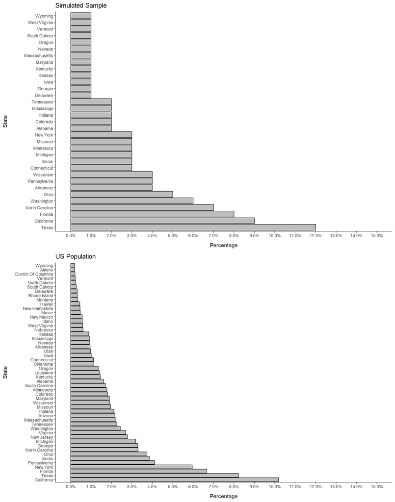

**NOTE**: Comparison of simulated versus ‘population’ data. The population percentage is an estimate based on census data. $n_{simulation}$ = 100; $n_{census}$ = 2,366,924. Both the simulated and ‘population’ data is based on data by the IPUMS (Ruggles et al. 2024) and ANES (2021).

#### 10.3.1.2 Ethnoracial Group

This section gives an overview of the distribution of ‘ethnoraces’ (i.e., a racial/ethnic/national label employed in the US) in the simulated data, as well as census-based estimates of the US population for comparison. This is provided metrically in table 10.2 and graphically in figure 10.2. With a sample size of 100, the simulated sample manages to capture 99.59% of the information about the ‘ethnoraces’ in the population.

Table 10.2: Distribution of Race/Ethnicity/Nationality

| Race/Ethnicity/Nationality | Sample Frequency | Sample Percentage (%) | Population Percentage (%) | Difference (pp) |
| --- | --- | --- | --- | --- |
| Argentinean | 0 | 0 | 0.085 | -0.085 |
| Bangladeshi | 0 | 0 | 0.073 | -0.073 |
| Bhutanese | 0 | 0 | 0.004 | -0.004 |
| Black/African American | 3 | 3 | 8.831 | -5.831 |
| Bolivian | 0 | 0 | 0.025 | -0.025 |
| Burmese | 0 | 0 | 0.049 | -0.049 |
| Cambodian | 0 | 0 | 0.088 | -0.088 |
| Chilean | 0 | 0 | 0.046 | -0.046 |
| Chinese | 3 | 3 | 1.709 | 1.291 |
| Colombian | 0 | 0 | 0.282 | -0.282 |
| Costa Rican | 0 | 0 | 0.038 | -0.038 |
| Cuban | 2 | 2 | 0.643 | 1.357 |
| Dominican | 0 | 0 | 0.245 | -0.245 |
| Ecuadorian | 0 | 0 | 0.105 | -0.105 |
| Fijian | 0 | 0 | 0.011 | -0.011 |
| Filipino | 1 | 1 | 1.155 | -0.155 |
| Guatemalan | 0 | 0 | 0.186 | -0.186 |
| Hawaiian | 0 | 0 | 0.050 | -0.050 |
| Honduran | 0 | 0 | 0.125 | -0.125 |
| Indian | 0 | 0 | 1.405 | -1.405 |
| Indonesian | 0 | 0 | 0.030 | -0.030 |
| Japanese | 0 | 0 | 0.314 | -0.314 |
| Korean | 0 | 0 | 0.541 | -0.541 |
| Laotian | 0 | 0 | 0.057 | -0.057 |
| Malaysian | 0 | 0 | 0.009 | -0.009 |
| Mexican | 5 | 5 | 5.417 | -0.417 |
| Mongolian | 0 | 0 | 0.007 | -0.007 |
| Native American | 0 | 0 | 0.856 | -0.856 |
| Nepalese | 0 | 0 | 0.060 | -0.060 |
| Nicaraguan | 0 | 0 | 0.081 | -0.081 |
| Pakistani | 0 | 0 | 0.172 | -0.172 |
| Panamanian | 0 | 0 | 0.051 | -0.051 |
| Paraguayan | 0 | 0 | 0.006 | -0.006 |
| Peruvian | 1 | 1 | 0.129 | 0.871 |
| Puerto Rican | 2 | 2 | 0.941 | 1.059 |
| Salvadoran | 0 | 0 | 0.250 | -0.250 |
| Spaniard | 0 | 0 | 0.251 | -0.251 |
| Sri Lankan | 0 | 0 | 0.020 | -0.020 |
| Taiwanese | 0 | 0 | 0.100 | -0.100 |
| Thai | 0 | 0 | 0.078 | -0.078 |
| Uruguayan | 0 | 0 | 0.018 | -0.018 |
| Venezuelan | 1 | 1 | 0.144 | 0.856 |
| Vietnamese | 2 | 2 | 0.663 | 1.337 |
| White | 80 | 80 | 74.647 | 5.353 |
| <NA> | 0 | 0 | 0.000 | 0.000 |
| Total | 100 | 100 | 100.000 | 0.000 |

**NOTE**: Comparison of simulated versus ‘population’ data. The population percentage is an estimate based on census data. $n_{simulation}$ = 100; $n_{census}$ = 2,366,924. pp = Percentage points. NA = Missing data. Both the simulated and ‘population’ data is based on data by the IPUMS (Ruggles et al. 2024) and ANES (2021).

Figure 10.2: Distribution of Race/Ethnicity/Nationality

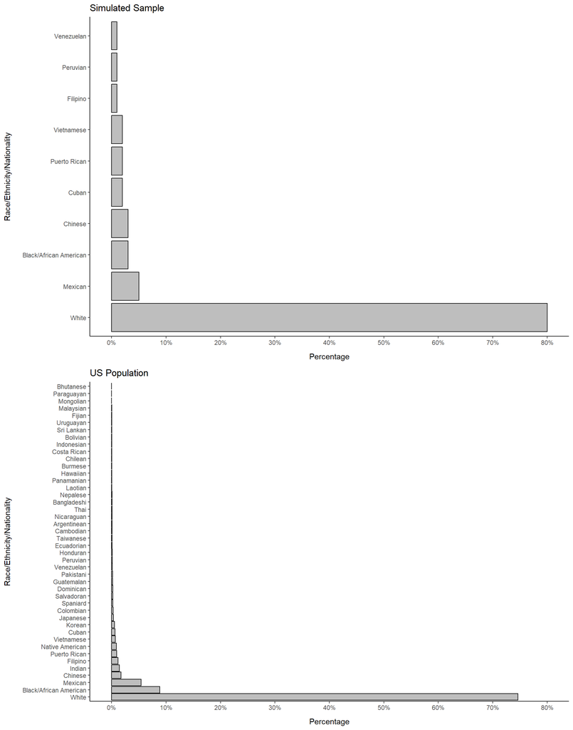

**NOTE**: Comparison of simulated versus ‘population’ data. The population percentage is an estimate based on census data. $n_{simulation}$ = 100; $n_{census}$ = 2,366,924. Both the simulated and ‘population’ data is based on data by the IPUMS (Ruggles et al. 2024) and ANES (2021).

#### 10.3.1.3 Education

This section gives an overview of the distribution of levels of education in the simulated data, as well as census-based estimates of the US population for comparison. This is provided metrically in table 10.3 and graphically in figure 10.3. With a sample size of 100, the simulated sample manages to capture 99.15% of the information about the levels of education in the population.

Table 10.3: Distribution of Education

| Education | Sample Frequency | Sample Percentage (%) | Population Percentage (%) | Difference (pp) |
| --- | --- | --- | --- | --- |
| Bachelor’s Degree | 23 | 23 | 21.93 | 1.069 |
| Graduate Degree | 10 | 10 | 14.57 | -4.570 |
| High School Credential | 31 | 31 | 26.45 | 4.555 |
| Less Than High School Credential | 7 | 7 | 8.31 | -1.311 |
| Some Post-High School, No Bachelor’s Degree | 29 | 29 | 28.74 | 0.258 |
| <NA> | 0 | 0 | 0.00 | 0.000 |
| Total | 100 | 100 | 100.00 | 0.000 |

**NOTE**: Comparison of simulated versus ‘population’ data. The population percentage is an estimate based on census data. $n_{simulation}$ = 100; $n_{census}$ = 2,366,924. pp = Percentage points. NA = Missing data. Both the simulated and ‘population’ data is based on data by the IPUMS (Ruggles et al. 2024) and ANES (2021).

Figure 10.3: Distribution of Education

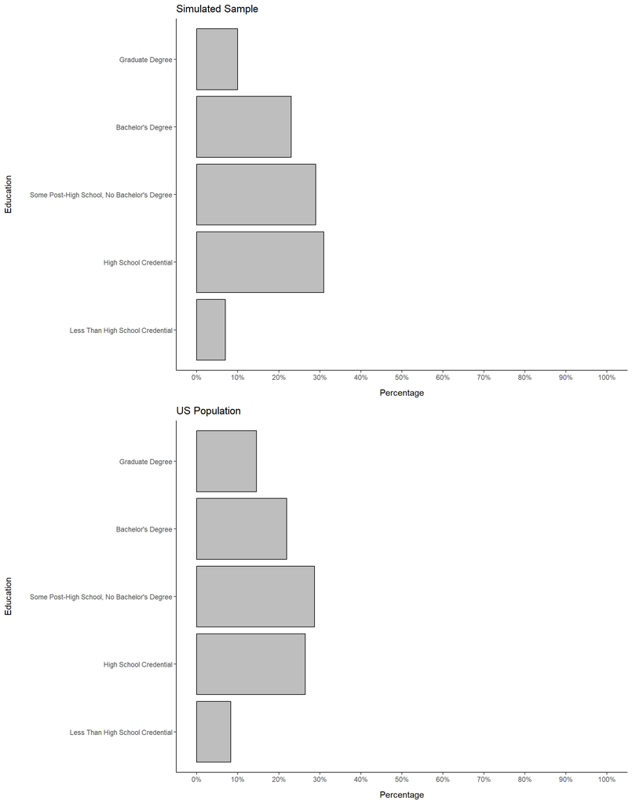

**NOTE**: Comparison of simulated versus ‘population’ data. The population percentage is an estimate based on census data. $n_{simulation}$ = 100; $n_{census}$ = 2,366,924. Both the simulated and ‘population’ data is based on data by the IPUMS (Ruggles et al. 2024) and ANES (2021).

#### 10.3.1.4 Age

This section gives an overview of the distribution of age in the simulated data, as well as census-based estimates of the US population for comparison. This is provided metrically in table 10.4 and graphically in figure 10.4. With a sample size of 100, the simulated sample manages to capture 78.10% of the information about age in the population.

Table 10.4: Distribution of Age

| Age | Sample Frequency | Sample Percentage (%) | Population Percentage (%) | Difference (pp) |
| --- | --- | --- | --- | --- |
| 18 | 2 | 2 | 1.206 | 0.794 |
| 19 | 1 | 1 | 1.049 | -0.049 |
| 21 | 2 | 2 | 1.142 | 0.858 |
| 23 | 2 | 2 | 1.237 | 0.763 |
| 24 | 2 | 2 | 1.253 | 0.747 |
| 25 | 1 | 1 | 1.290 | -0.290 |
| 26 | 2 | 2 | 1.311 | 0.689 |
| 27 | 1 | 1 | 1.349 | -0.349 |
| 28 | 1 | 1 | 1.383 | -0.383 |
| 29 | 2 | 2 | 1.413 | 0.587 |
| 31 | 2 | 2 | 1.504 | 0.496 |
| 32 | 1 | 1 | 1.550 | -0.550 |
| 33 | 2 | 2 | 1.520 | 0.480 |
| 34 | 1 | 1 | 1.496 | -0.496 |
| 35 | 2 | 2 | 1.513 | 0.487 |
| 37 | 1 | 1 | 1.520 | -0.520 |
| 38 | 1 | 1 | 1.507 | -0.507 |
| 39 | 1 | 1 | 1.500 | -0.500 |
| 40 | 2 | 2 | 1.558 | 0.442 |
| 41 | 3 | 3 | 1.509 | 1.491 |
| 42 | 2 | 2 | 1.515 | 0.485 |
| 44 | 2 | 2 | 1.429 | 0.571 |
| 45 | 1 | 1 | 1.432 | -0.432 |
| 47 | 2 | 2 | 1.410 | 0.590 |
| 49 | 1 | 1 | 1.427 | -0.427 |
| 50 | 2 | 2 | 1.565 | 0.435 |
| 51 | 2 | 2 | 1.642 | 0.358 |
| 53 | 5 | 5 | 1.597 | 3.403 |
| 54 | 1 | 1 | 1.570 | -0.570 |
| 56 | 2 | 2 | 1.649 | 0.351 |
| 58 | 2 | 2 | 1.825 | 0.175 |
| 59 | 1 | 1 | 1.851 | -0.851 |
| 60 | 1 | 1 | 1.910 | -0.910 |
| 62 | 1 | 1 | 1.973 | -0.973 |
| 63 | 2 | 2 | 1.938 | 0.062 |
| 64 | 2 | 2 | 1.967 | 0.033 |
| 65 | 7 | 7 | 1.974 | 5.026 |
| 66 | 3 | 3 | 1.904 | 1.096 |
| 67 | 3 | 3 | 1.862 | 1.138 |
| 68 | 2 | 2 | 1.831 | 0.169 |
| 69 | 3 | 3 | 1.770 | 1.230 |
| 70 | 1 | 1 | 1.709 | -0.709 |
| 71 | 2 | 2 | 1.618 | 0.382 |
| 72 | 2 | 2 | 1.562 | 0.438 |
| 73 | 3 | 3 | 1.516 | 1.484 |
| 74 | 3 | 3 | 1.487 | 1.513 |
| 77 | 1 | 1 | 1.029 | -0.029 |
| 79 | 2 | 2 | 0.976 | 1.024 |
| 81 | 1 | 1 | 0.736 | 0.264 |
| 83 | 1 | 1 | 0.600 | 0.400 |
| 84 | 1 | 1 | 0.531 | 0.469 |
| 85 | 2 | 2 | 0.462 | 1.538 |
| 86 | 2 | 2 | 0.408 | 1.592 |
| <NA> | 0 | 0 | 0.000 | 0.000 |
| Total | 100 | 100 | 100.000 | 0.000 |

**NOTE**: Comparison of simulated versus ‘population’ data. The population percentage is an estimate based on census data. $n_{simulation}$ = 100; $n_{census}$ = 2,366,924. pp = Percentage points. NA = Missing data. Both the simulated and ‘population’ data is based on data by the IPUMS (Ruggles et al. 2024) and ANES (2021).

Figure 10.4: Distribution of Age

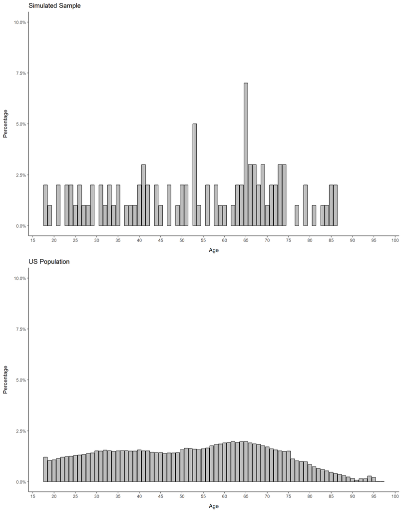

**NOTE**: Comparison of simulated versus ‘population’ data. The population percentage is an estimate based on census data. $n_{simulation}$ = 100; $n_{census}$ = 2,366,924. Both the simulated and ‘population’ data is based on data by the IPUMS (Ruggles et al. 2024) and ANES (2021).

#### 10.3.1.5 Household Income

This section gives an overview of the distribution of household incomes ($US) in the simulated data, as well as census-based estimates of the US population for comparison. This is provided metrically in table 10.5 and graphically in figure 10.5. With a sample size of 100, the simulated sample manages to capture 45.45% of the information about household incomes in the population.

Table 10.5: Distribution of Household Incomes

| Household Income ($US) | Sample Frequency | Sample Percentage (%) | Population Percentage (%) | Difference (pp) |
| --- | --- | --- | --- | --- |
| 0 | 3 | 3 | 1.030 | 1.970 |
| 103000 | 1 | 1 | 0.182 | 0.818 |
| 107200 | 1 | 1 | 0.024 | 0.976 |
| 110000 | 1 | 1 | 0.460 | 0.540 |
| 112000 | 1 | 1 | 0.194 | 0.806 |
| 112200 | 1 | 1 | 0.022 | 0.978 |
| 112400 | 1 | 1 | 0.021 | 0.979 |
| 114000 | 2 | 2 | 0.158 | 1.842 |
| 119000 | 1 | 1 | 0.124 | 0.876 |
| 120000 | 1 | 1 | 0.516 | 0.484 |
| 120300 | 1 | 1 | 0.017 | 0.983 |
| 124100 | 1 | 1 | 0.014 | 0.986 |
| 124600 | 1 | 1 | 0.017 | 0.983 |
| 124900 | 1 | 1 | 0.011 | 0.989 |
| 126000 | 1 | 1 | 0.143 | 0.857 |
| 127600 | 1 | 1 | 0.019 | 0.981 |
| 130000 | 2 | 2 | 0.411 | 1.589 |
| 132000 | 2 | 2 | 0.154 | 1.846 |
| 136000 | 2 | 2 | 0.127 | 1.873 |
| 143600 | 1 | 1 | 0.015 | 0.985 |
| 14900 | 1 | 1 | 0.027 | 0.973 |
| 15000 | 1 | 1 | 0.236 | 0.764 |
| 150000 | 1 | 1 | 0.416 | 0.584 |
| 154000 | 1 | 1 | 0.098 | 0.902 |
| 156400 | 1 | 1 | 0.011 | 0.989 |
| 163000 | 1 | 1 | 0.096 | 0.904 |
| 16400 | 1 | 1 | 0.033 | 0.967 |
| 164300 | 1 | 1 | 0.009 | 0.991 |
| 166200 | 1 | 1 | 0.011 | 0.989 |
| 168400 | 1 | 1 | 0.011 | 0.989 |

[output cut: 63 more lines]

**NOTE**: Comparison of simulated versus ‘population’ data. The population percentage is an estimate based on census data. $n_{simulation}$ = 100; $n_{census}$ = 2,366,924. pp = Percentage points. NA = Missing data. Both the simulated and ‘population’ data is based on data by the IPUMS (Ruggles et al. 2024) and ANES (2021).

Figure 10.5: Distribution of Household Incomes

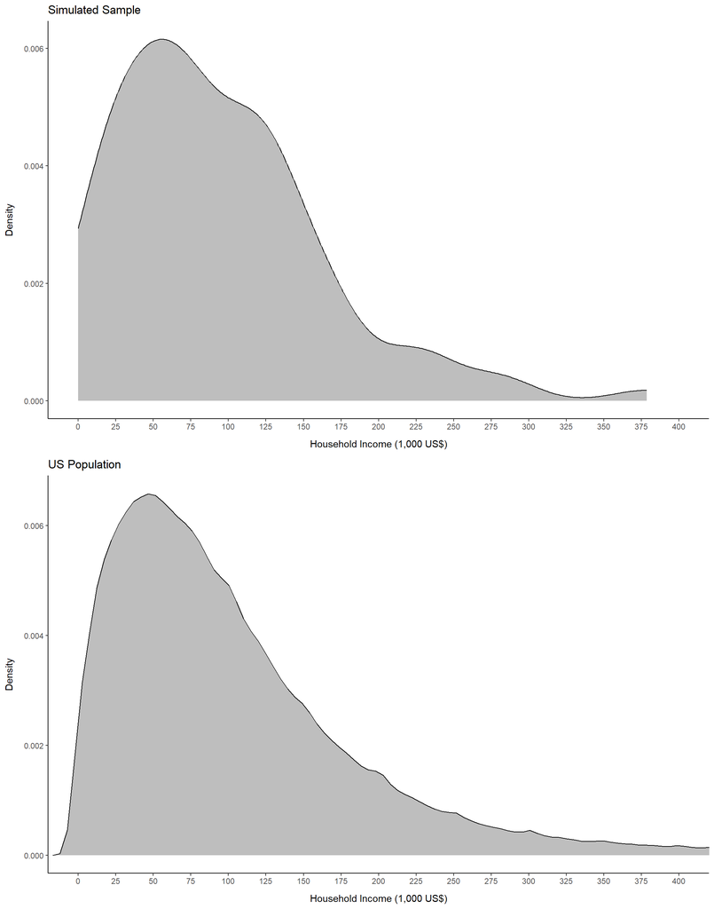

**NOTE**: Comparison of simulated versus ‘population’ data. The population percentage is an estimate based on census data. $n_{simulation}$ = 100; $n_{census}$ = 2,366,924. Both the simulated and ‘population’ data is based on data by the IPUMS (Ruggles et al. 2024) and ANES (2021).

#### 10.3.1.6 Number of Children

This section gives an overview of the distribution of children in the simulated data, as well as census-based estimates of the US population for comparison. This is provided metrically in table 10.6 and graphically in figure 10.6. With a sample size of 100, the simulated sample manages to capture 99.76% of the information about children in the population.

Table 10.6: Distribution of Children

| Number of Children | Sample Frequency | Sample Percentage (%) | Population Percentage (%) | Difference (pp) |
| --- | --- | --- | --- | --- |
| 0 | 69 | 69 | 65.39 | 3.61 |
| 1 | 14 | 14 | 17.07 | -3.07 |
| 2 | 14 | 14 | 11.52 | 2.48 |
| 3 | 3 | 3 | 4.23 | -1.23 |
| 4 Or More | 0 | 0 | 1.80 | -1.80 |
| <NA> | 0 | 0 | 0.00 | 0.00 |
| Total | 100 | 100 | 100.00 | 0.00 |

**NOTE**: Comparison of simulated versus ‘population’ data. The population percentage is an estimate based on census data. $n_{simulation}$ = 100; $n_{census}$ = 2,366,924. pp = Percentage points. NA = Missing data. Both the simulated and ‘population’ data is based on data by the IPUMS (Ruggles et al. 2024) and ANES (2021).

Figure 10.6: Distribution of Children

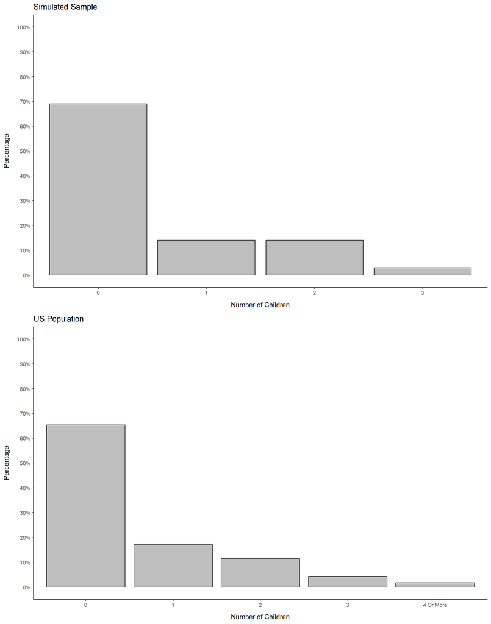

**NOTE**: Comparison of simulated versus ‘population’ data. The population percentage is an estimate based on census data. $n_{simulation}$ = 100; $n_{census}$ = 2,366,924. Both the simulated and ‘population’ data is based on data by the IPUMS (Ruggles et al. 2024) and ANES (2021).

#### 10.3.1.7 Area of Residence

This section gives an overview of the distribution of area residencies in the simulated data, as well as census-based estimates of the US population for comparison. This is provided metrically in table 10.7 and graphically in figure 10.7. With a sample size of 100, the simulated sample manages to capture 99.01% of the information about area residencies in the population.

Table 10.7: Distribution of Area Residencies

| Area Residence | Sample Frequency | Sample Percentage (%) | Population Percentage (%) | Difference (pp) |
| --- | --- | --- | --- | --- |
| City | 5 | 5 | 10.9 | -5.87 |
| Rural Area | 20 | 20 | 10.9 | 9.05 |
| Small Town Or Surburb | 75 | 75 | 78.2 | -3.18 |
| <NA> | 0 | 0 | 0.0 | 0.00 |
| Total | 100 | 100 | 100.0 | 0.00 |

**NOTE**: Comparison of simulated versus ‘population’ data. The population percentage is an estimate based on census data. $n_{simulation}$ = 100; $n_{census}$ = 2,366,924. pp = Percentage points. NA = Missing data. Both the simulated and ‘population’ data is based on data by the IPUMS (Ruggles et al. 2024) and ANES (2021).

Figure 10.7: Distribution of Area Residencies

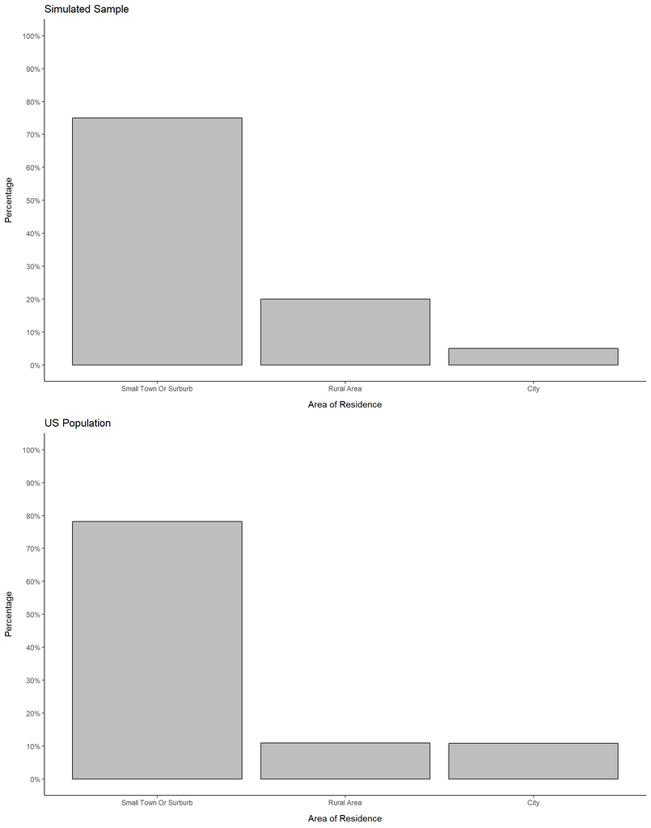

**NOTE**: Comparison of simulated versus ‘population’ data. The population percentage is an estimate based on census data. $n_{simulation}$ = 100; $n_{census}$ = 2,366,924. Both the simulated and ‘population’ data are based on data by the IPUMS (Ruggles et al. 2024) and ANES (2021).

#### 10.3.1.8 Sex

This section gives an overview of the distribution of sex in the simulated data, as well as census-based estimates of the US population for comparison. This is provided metrically in table 10.8 and graphically in figure 10.8. With a sample size of 100, the simulated sample manages to capture 99.99% of the information about sex in the population.

Table 10.8: Distribution of Sexes

| Sex | Sample Frequency | Sample Percentage (%) | Population Percentage (%) | Difference (pp) |
| --- | --- | --- | --- | --- |
| Female | 53 | 53 | 52.2 | 0.76 |
| Male | 47 | 47 | 47.8 | -0.76 |
| <NA> | 0 | 0 | 0.0 | 0.00 |
| Total | 100 | 100 | 100.0 | 0.00 |

**NOTE**: Comparison of simulated versus ‘population’ data. The population percentage is an estimate based on census data. $n_{simulation}$ = 100; $n_{census}$ = 2,366,924. pp = Percentage points. NA = Missing data. Both the simulated and ‘population’ data is based on data by the IPUMS (Ruggles et al. 2024) and ANES (2021).

Figure 10.8: Distribution of Sexes

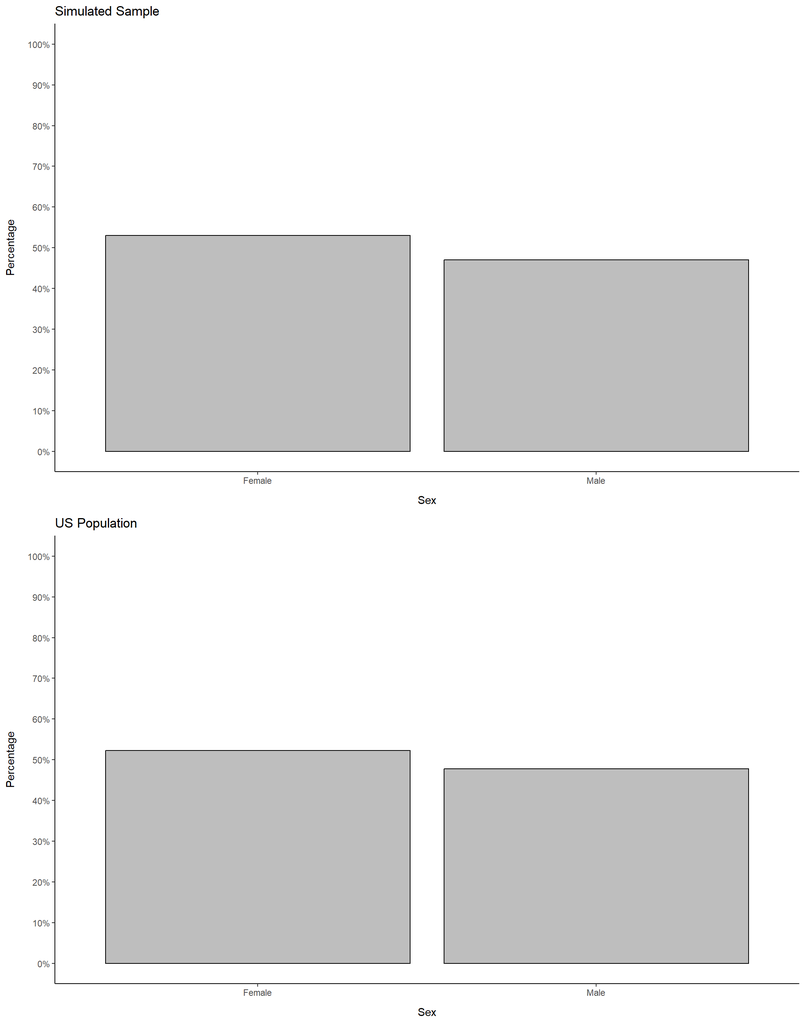

**NOTE**: Comparison of simulated versus ‘population’ data. The population percentage is an estimate based on census data. $n_{simulation}$ = 100; $n_{census}$ = 2,366,924. Both the simulated and ‘population’ data are based on data by the IPUMS (Ruggles et al. 2024) and ANES (2021).

#### 10.3.1.9 Marital Status

This section gives an overview of the distribution of marital status in the simulated data, as well as census-based estimates of the US population for comparison. This is provided metrically in table 10.9 and graphically in figure 10.9. With a sample size of 100, the simulated sample manages to capture 99.54% of the information about marital status in the population.

Table 10.9: Distribution of Marital Status

| Marital Status | Sample Frequency | Sample Percentage (%) | Population Percentage (%) | Difference (pp) |
| --- | --- | --- | --- | --- |
| Divorced | 11 | 11 | 11.35 | -0.354 |
| Married | 58 | 58 | 56.67 | 1.327 |
| Not Married | 20 | 20 | 23.80 | -3.803 |
| Separated | 0 | 0 | 1.42 | -1.424 |
| Widowed | 11 | 11 | 6.75 | 4.253 |
| <NA> | 0 | 0 | 0.00 | 0.000 |
| Total | 100 | 100 | 100.00 | 0.000 |

**NOTE**: Comparison of simulated versus ‘population’ data. The population percentage is an estimate based on census data. $n_{simulation}$ = 100; $n_{census}$ = 2,366,924. pp = Percentage points. NA = Missing data. Both the simulated and ‘population’ data is based on data by the IPUMS (Ruggles et al. 2024) and ANES (2021).

Figure 10.9: Distribution of Marital Status

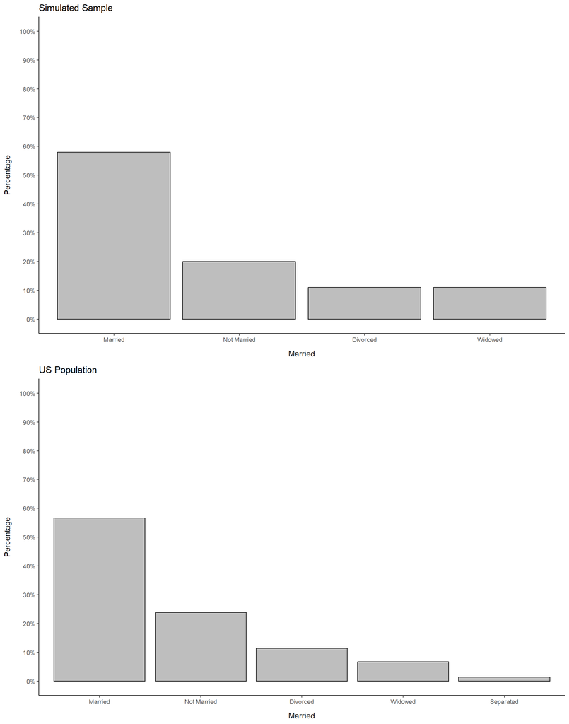

**NOTE**: Comparison of simulated versus ‘population’ data. The population percentage is an estimate based on census data. $n_{simulation}$ = 100; $n_{census}$ = 2,366,924. Both the simulated and ‘population’ data are based on data by the IPUMS (Ruggles et al. 2024) and ANES (2021).

#### 10.3.1.10 Employment Status

This section gives an overview of the distribution of employment status in the simulated data, as well as census-based estimates of the US population for comparison. This is provided metrically in table 10.10 and graphically in figure 10.10. With a sample size of 100, the simulated sample manages to capture 99.36% of the information about employment status in the population.

Table 10.10: Distribution of Employment Status

| Employment Status | Sample Frequency | Sample Percentage (%) | Population Percentage (%) | Difference (pp) |
| --- | --- | --- | --- | --- |
| Employed | 53 | 53 | 59.05 | -6.054 |
| Not In Labor Force | 44 | 44 | 38.67 | 5.327 |
| Unemployed | 3 | 3 | 2.27 | 0.726 |
| <NA> | 0 | 0 | 0.00 | 0.000 |
| Total | 100 | 100 | 100.00 | 0.000 |

**NOTE**: Comparison of simulated versus ‘population’ data. The population percentage is an estimate based on census data. $n_{simulation}$ = 100; $n_{census}$ = 2,366,924. pp = Percentage points. NA = Missing data. Both the simulated and ‘population’ data is based on data by the IPUMS (Ruggles et al. 2024) and ANES (2021).

Figure 10.10: Distribution of Employment Status

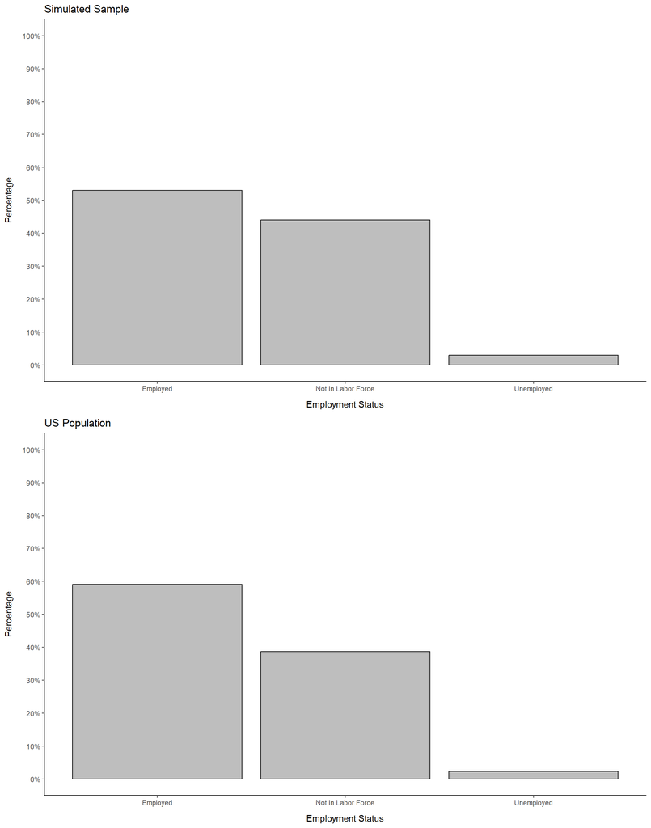

**NOTE**: Comparison of simulated versus ‘population’ data. The population percentage is an estimate based on census data. $n_{simulation}$ = 100; $n_{census}$ = 2,366,924. Both the simulated and ‘population’ data is based on data by the IPUMS (Ruggles et al. 2024) and ANES (2021).

#### 10.3.1.11 Political Party

This section gives an overview of the distribution of political parties in the simulated data, as well as census-based estimates of the US population for comparison. This is provided metrically in table 10.11 and graphically in figure 10.11. With a sample size of 100, the simulated sample manages to capture 96.00% of the information about political parties in the population.

Table 10.11: Distribution of Preferred Political Parties

| Political Party | Sample Frequency | Sample Percentage (%) | Population Percentage (%) | Difference (pp) |
| --- | --- | --- | --- | --- |
| Democratic Party | 41 | 41 | 55.3 | -14.3 |
| Republican Party | 59 | 59 | 44.7 | 14.3 |
| <NA> | 0 | 0 | 0.0 | 0.0 |
| Total | 100 | 100 | 100.0 | 0.0 |

**NOTE**: Comparison of simulated versus ‘population’ data. The population percentage is an estimate based on census data. $n_{simulation}$ = 100; $n_{census}$ = 2,366,924. pp = Percentage points. NA = Missing data. Both the simulated and ‘population’ data is based on data by the IPUMS (Ruggles et al. 2024) and ANES (2021).

Figure 10.11: Distribution of Preferred Political Parties

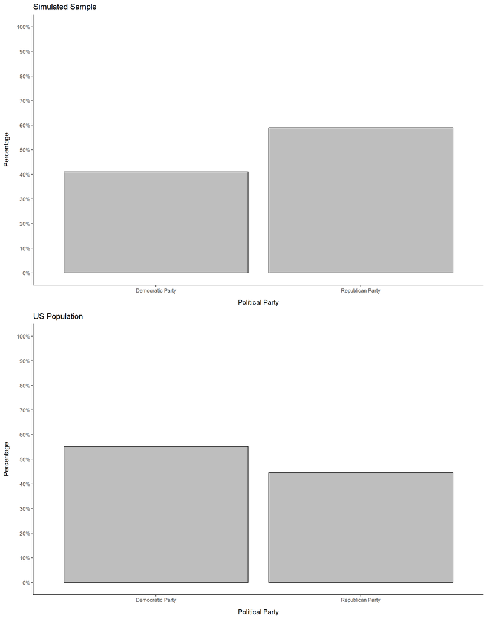

**NOTE**: Comparison of simulated versus ‘population’ data. The population percentage is an estimate based on census data. $n_{simulation}$ = 100; $n_{census}$ = 2,366,924. Both the simulated and ‘population’ data are based on data by the IPUMS (Ruggles et al. 2024) and ANES (2021).

#### 10.3.1.12 Political Ideology

This section gives an overview of the distribution of political ideologies in the simulated data, as well as census-based estimates of the US population for comparison. This is provided metrically in table 10.12 and graphically in figure 10.12. With a sample size of 100, the simulated sample manages to capture 96.33% of the information about political ideologies in the population.

Table 10.12: Distribution of Political Ideologies

| Political Ideology | Sample Frequency | Sample Percentage (%) | Population Percentage (%) | Difference (pp) |
| --- | --- | --- | --- | --- |
| Extremely Liberal | 0 | 0 | 0.503 | -0.503 |
| Liberal | 12 | 12 | 19.982 | -7.982 |
| Slightly Liberal | 2 | 2 | 6.233 | -4.233 |
| Moderate; Middle Of The Road | 28 | 28 | 29.519 | -1.519 |
| Slightly Conservative | 0 | 0 | 2.313 | -2.313 |
| Conservative | 57 | 57 | 40.395 | 16.605 |
| Extremely Conservative | 1 | 1 | 1.056 | -0.056 |
| <NA> | 0 | 0 | 0.000 | 0.000 |
| Total | 100 | 100 | 100.000 | 0.000 |

**NOTE**: Comparison of simulated versus ‘population’ data. The population percentage is an estimate based on census data. $n_{simulation}$ = 100; $n_{census}$ = 2,366,924. pp = Percentage points. NA = Missing data. Both the simulated and ‘population’ data is based on data by the IPUMS (Ruggles et al. 2024) and ANES (2021).

Figure 10.12: Distribution of Political Ideologies

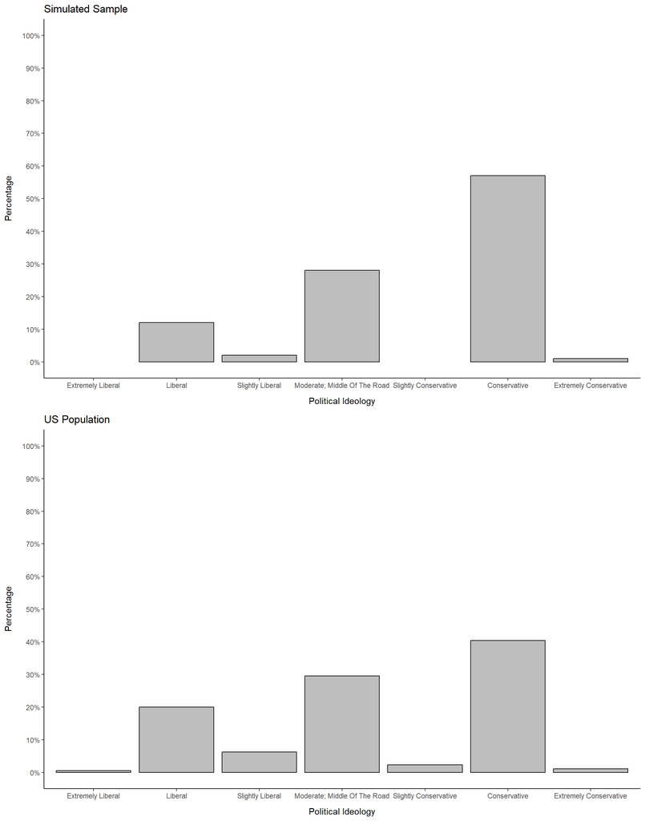

**NOTE**: Comparison of simulated versus ‘population’ data. The population percentage is an estimate based on census data. $n_{simulation}$ = 100; $n_{census}$ = 2,366,924. Both the simulated and ‘population’ data are based on data by the IPUMS (Ruggles et al. 2024) and ANES (2021).

### 10.3.2 Synthetic Data

#### 10.3.2.1 Welfare Support

The distribution of welfare support in the synthetic data is provided metrically in table 10.13 and graphically in figure 10.13.

Table 10.13: Distribution of Support for Restricting Welfare Eligibility

| Support for Restricting Welfare Eligibility | Control Frequency | Control Percentage (%) | Treatment Frequency | Treatment Percentage (%) | Difference (pp) |
| --- | --- | --- | --- | --- | --- |
| Strongly Disagree | 2 | 2 | 100 | 100 | -98 |
| Disagree | 37 | 37 | 0 | 0 | 37 |
| Neither agree nor disagree | 3 | 3 | 0 | 0 | 3 |
| Agree | 58 | 58 | 0 | 0 | 58 |
| Strongly Agree | 0 | 0 | 0 | 0 | 0 |
| <NA> | 0 | 0 | 0 | 0 | 0 |
| Total | 100 | 100 | 100 | 100 | 0 |

**NOTE**: Comparison of support for restricting welfare eligibility across group conditions. n = 100. Synthetic data generated by OpenAI’s (2024a) gpt-4o-mini model based on vignettes and questions created by (Aarøe and Petersen 2014) and data by the IPUMS (Ruggles et al. 2024) and ANES (2021).

Figure 10.13: Distribution of Support for Restricting Welfare Eligibility

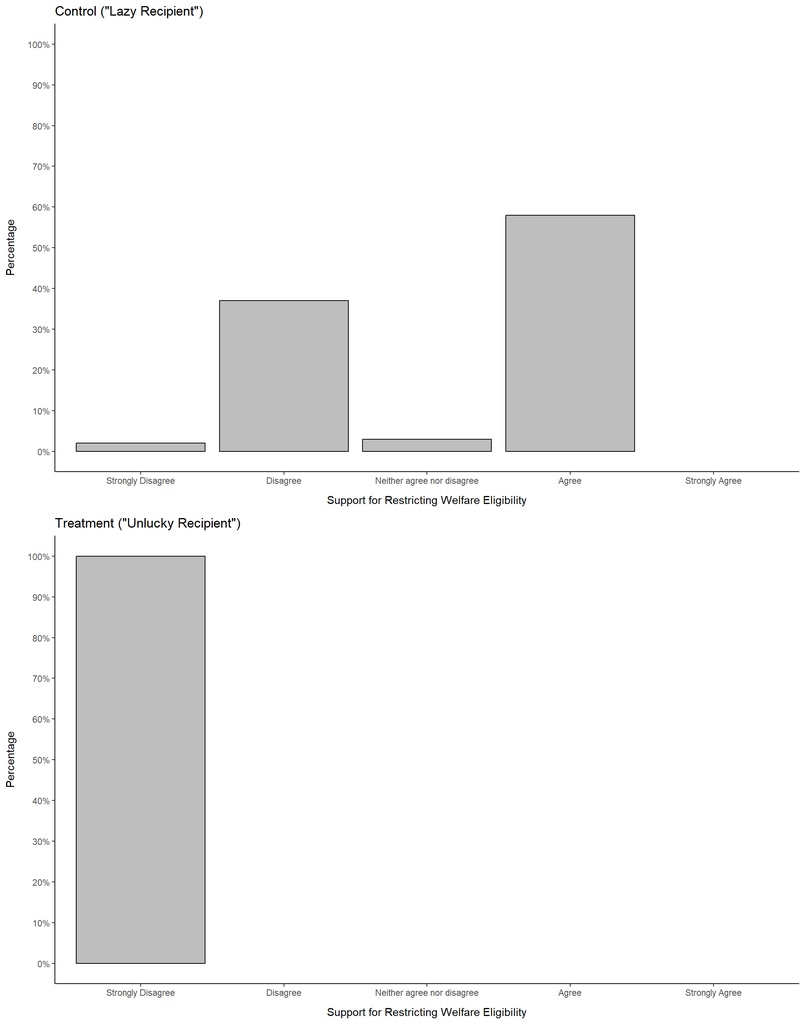

**NOTE**: Comparison of support for restricting welfare eligibility across group conditions. n = 100. Synthetic data generated by OpenAI’s (2024a) gpt-4o-mini model based on vignettes and questions created by (Aarøe and Petersen 2014) and data by the IPUMS (Ruggles et al. 2024) and ANES (2021).

#### 10.3.2.2 Individual Treatment Effect

Table 10.14: Distribution of Individual Treatment Effects

| $\hat{\tau}_i$ | Frequency | Percentage (%) |
| --- | --- | --- |
| 0 | 2 | 2 |
| 0.333333333333333 | 37 | 37 |
| 0.666666666666667 | 3 | 3 |
| 1 | 58 | 58 |
| <NA> | 0 | NA |
| Total | 100 | 100 |

**NOTE**: Normalized (0-1) estimates of individual treatment effects ($\hat{\tau}_i$, ITEs) of social deservingness on welfare support. n = 100. Synthetic data generated by OpenAI’s (2024a) gpt-4o-mini model based on vignettes and questions created by (Aarøe and Petersen 2014) and data by the IPUMS (Ruggles et al. 2024) and ANES (2021).

Figure 10.14: Distribution of Individual Treatment Effect

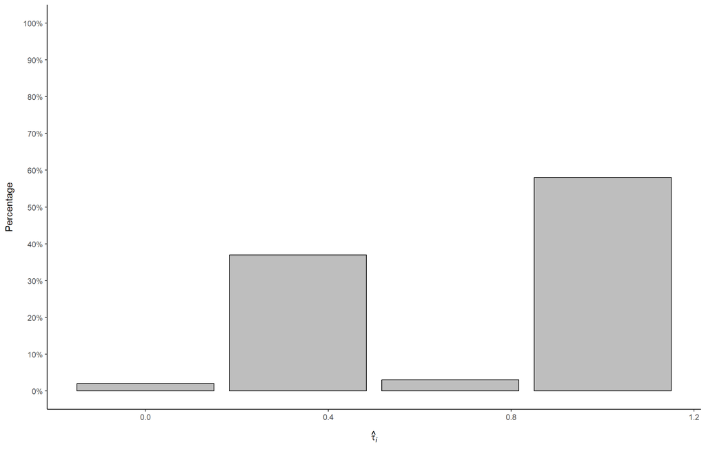

**NOTE**: Normalized (0-1) estimates of individual treatment effects ($\hat{\tau}_i$, ITEs) of social deservingness on welfare support. n = 100. Synthetic data generated by OpenAI’s (2024a) gpt-4o-mini model based on vignettes and questions created by (Aarøe and Petersen 2014) and data by the IPUMS (Ruggles et al. 2024) and ANES (2021).

#### 10.3.2.3 Simultaneity Test

A traceplot of chain convergence of the Bayesian Generalized Linear Model (BGLM) for testing the simultaneity assumption is provided graphically in 10.15, while the model’s goodness-of-fit is provided as a posterior predictive plot in figure 10.16, as residual dispersion ($\sigma$) in 10.17, and as explained variance ($R^2$) in figure 10.18.

Figure 10.15: Chain Convergence of the Simultaneity Test BGLM

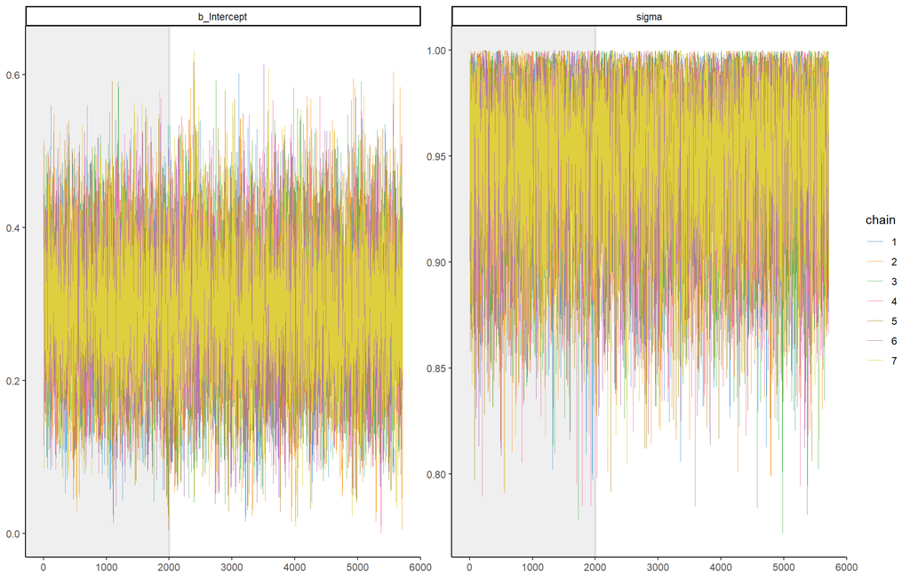

**NOTE**: Traceplot. Total chains = 7, total samples per chain = 7,715, warmup samples per chain = 2,000. Total posterior samples = 40,000. Synthetic data generated by OpenAI’s (2024a) gpt-4o-mini model based on vignettes and questions created by (Aarøe and Petersen 2014) and data by the IPUMS (Ruggles et al. 2024) and ANES (2021).

Figure 10.16: Posterior Predictive Distribution of the Simultaneity Test BGLM

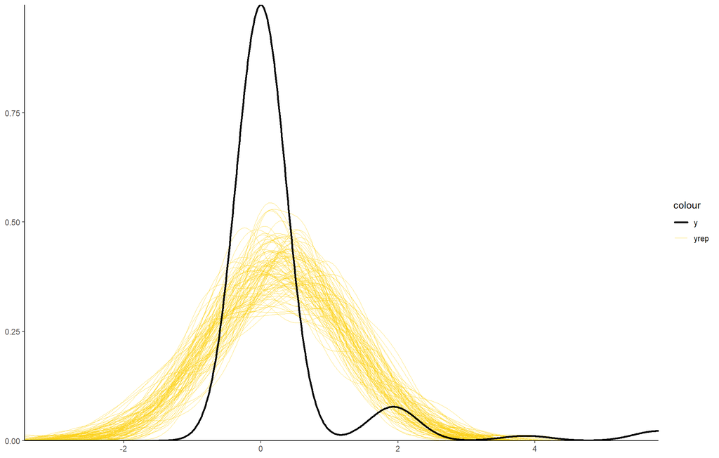

**NOTE**: Traceplot with 100 random draws shown. Posterior samples = 40,000. Synthetic data generated by OpenAI’s (2024a) gpt-4o-mini model based on vignettes and questions created by (Aarøe and Petersen 2014) and data by the IPUMS (Ruggles et al. 2024) and ANES (2021).

Figure 10.17: Residual Dispersion of the Simultaneity Test BGLM

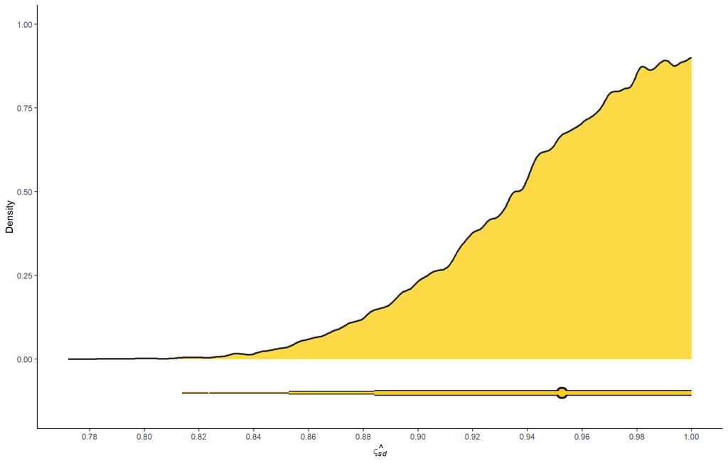

**NOTE**: Posterior distribution of the estimated residual dispersion parameter ($\sigma$). Posterior samples = 40,000. Synthetic data generated by OpenAI’s (2024a) gpt-4o-mini model based on vignettes and questions created by (Aarøe and Petersen 2014) and data by the IPUMS (Ruggles et al. 2024) and ANES (2021).

Figure 10.18: Explanatory Power of Simultaneity Test BGLM

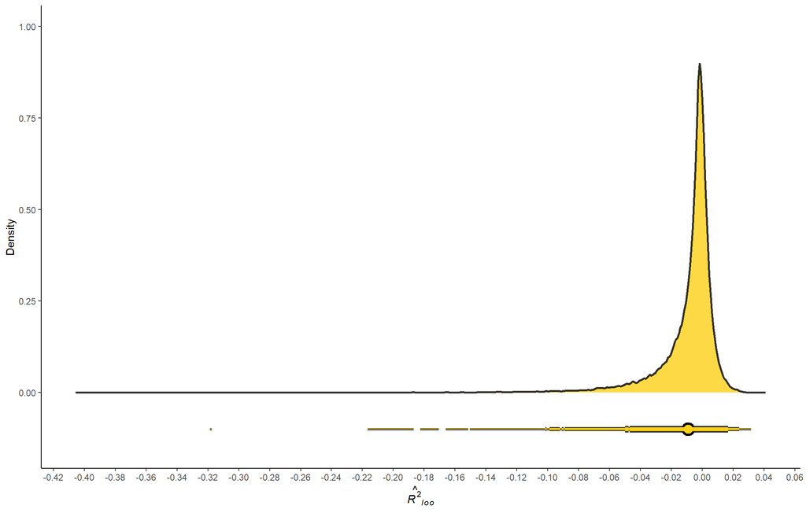

**NOTE**: Posterior distribution of the estimated, loo-adjusted explained variance ($R^2$). Posterior samples = 40,000. Synthetic data generated by OpenAI’s (2024a) gpt-4o-mini model based on vignettes and questions created by (Aarøe and Petersen 2014) and data by the IPUMS (Ruggles et al. 2024) and ANES (2021).

#### 10.3.2.4 Social Deservingness & Welfare Support

Figure 10.19: Chain Convergence of the Social Deservingness & Welfare Support ML-BGLM

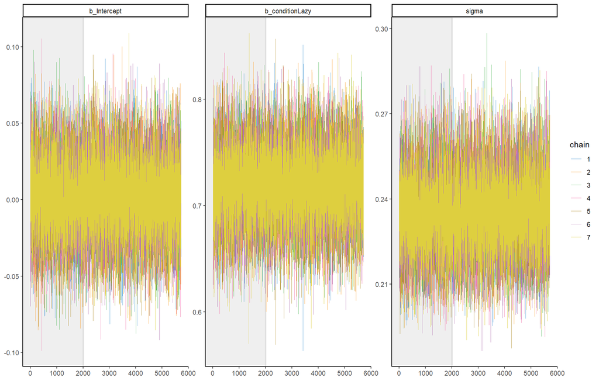

**NOTE**: Traceplot. Total chains = 7, total samples per chain = 7,715, warmup samples per chain = 2,000. Total posterior samples = 40,000. Synthetic data generated by OpenAI’s (2024a) gpt-4o-mini model based on vignettes and questions created by (Aarøe and Petersen 2014) and data by the IPUMS (Ruggles et al. 2024) and ANES (2021).

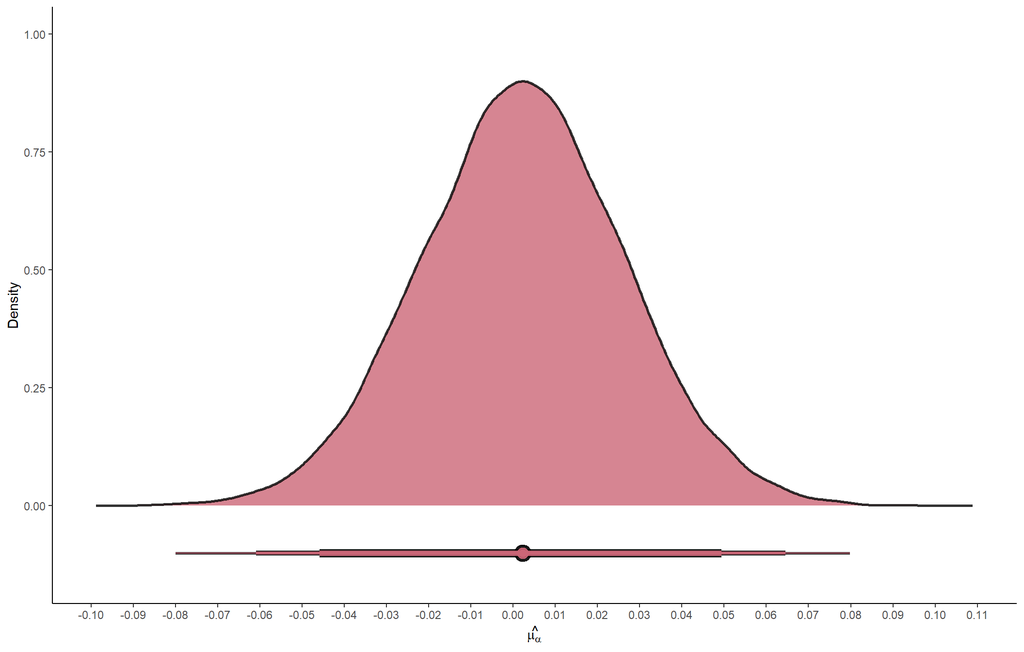

**NOTE**: Posterior distribution of the estimated intercept mean parameter ($\mu_\alpha$). Posterior samples = 40,000. Synthetic data generated by OpenAI’s (2024a) gpt-4o-mini model based on vignettes and questions created by (Aarøe and Petersen 2014) and data by the IPUMS (Ruggles et al. 2024) and ANES (2021).

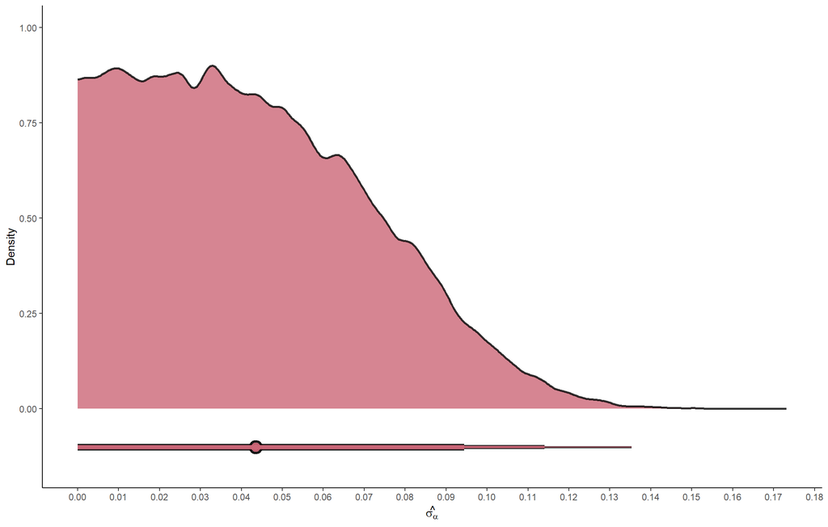

**NOTE**: Posterior distribution of the estimated intercept dispersion parameter ($\sigma_\alpha$). Posterior samples = 40,000. Synthetic data generated by OpenAI’s (2024a) gpt-4o-mini model based on vignettes and questions created by (Aarøe and Petersen 2014) and data by the IPUMS (Ruggles et al. 2024) and ANES (2021).

Figure 10.22: Posterior Predictive Distribution of the Social Deservingness & Welfare Support ML-BGLM

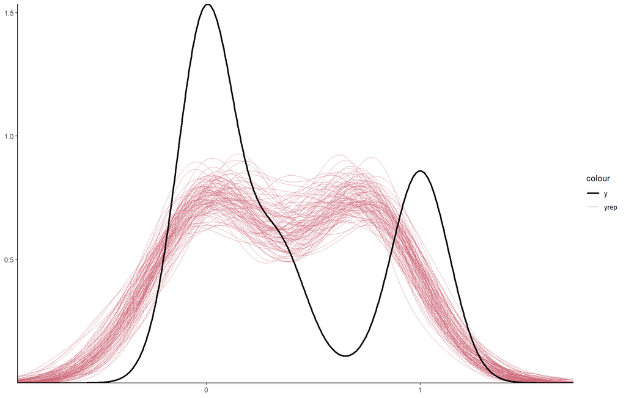

**NOTE**: Traceplot with 100 random draws shown. Posterior samples = 40,000. Synthetic data generated by OpenAI’s (2024a) gpt-4o-mini model based on vignettes and questions created by (Aarøe and Petersen 2014) and data by the IPUMS (Ruggles et al. 2024) and ANES (2021).

Figure 10.23: Residual Dispersion of the Social Deservingness & Welfare Support ML-BGLM

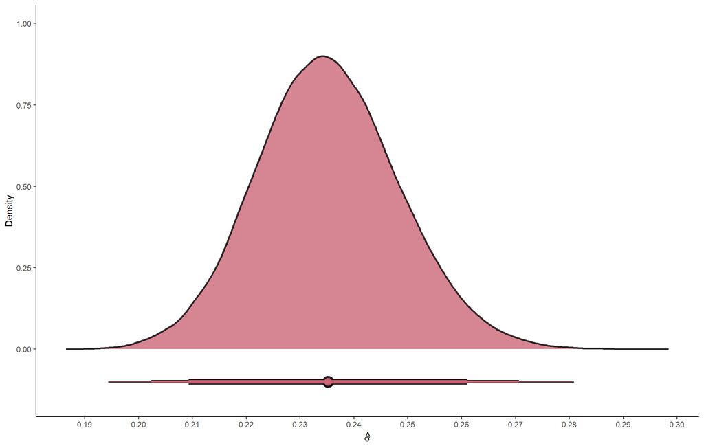

**NOTE**: Posterior distribution of the estimated residual dispersion parameter ($\sigma$). Posterior samples = 40,000. Synthetic data generated by OpenAI’s (2024a) gpt-4o-mini model based on vignettes and questions created by (Aarøe and Petersen 2014) and data by the IPUMS (Ruggles et al. 2024) and ANES (2021).

Figure 10.24: Explanatory Power of the Social Deservingness & Welfare Support ML-BGLM

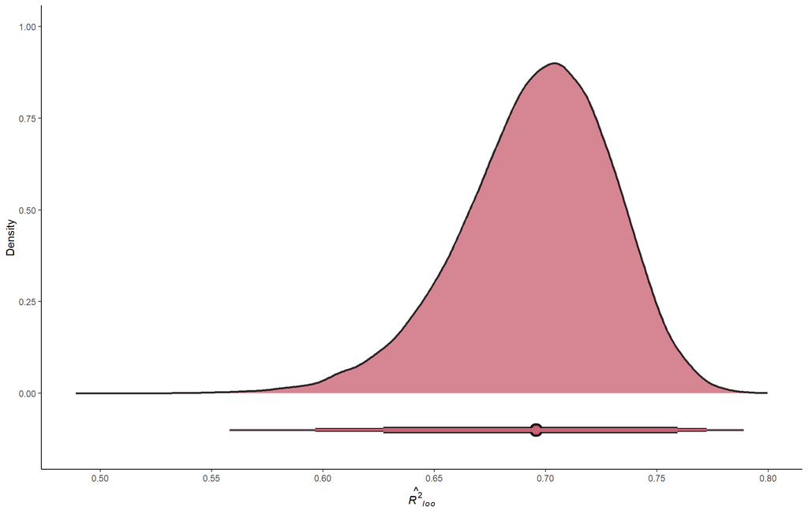

**NOTE**: Posterior distribution of the estimated, loo-adjusted explained variance ($R^2$). Posterior samples = 40,000. Synthetic data generated by OpenAI’s (2024a) gpt-4o-mini model based on vignettes and questions created by (Aarøe and Petersen 2014) and data by the IPUMS (Ruggles et al. 2024) and ANES (2021).

## 10.4 Citation

The *Synthetic Causal Framework* (SCF) and its implementation as the *Synthetically Controlled Trial* (SCT) are original concepts by Emil Meyer-Hansen, conceived as part of the author’s PhD project proposal for Aarhus University (submitted 2024-9-5, will be made freely available at a later date). In their current states, Emil Meyer-Hansen is the sole author and contributor to their ongoing development, conceptualization, formalization, and implementation. To follow the ongoing development, visit: (https://github.com/emeyer-hansen/synthetic_causal_framework). For correspondence, contact the author via email: emil098meyerhansen@gmail.com.

Please, if you use, refer to, and/or continue the development of the SCF and/or SCT, provide proper reference and citation to their original author. An example of proper citation is provided below:

- Meyer-Hansen, E. (2024): ‘The Synthetic Causal Framework: An NLP-based Solution to the Fundamental Problem of Causal Inference’, version 2024-10-16-15-18, Preview on *GitHub*: (https://github.com/emeyer-hansen/synthetic_causal_framework).

For LaTeX users, a BibTeX entry is provided below:

```r
@Manual{,
  title = {The Synthetic Causal Framework: An NLP-based Solution to the Fundamental Problem of Causal Inference},
  author = {Emil Meyer-Hansen},
  publisher = {GitHub},
  year = {2024},
  url = {https://github.com/emeyer-hansen/synthetic_causal_framework},
  note = {Preview Version}
}
```

[^1]: Independent researcher. Holds a Master of Science (MSc.) in Political Science from Aarhus University. Email: emil098meyerhansen@gmail.com
[^2]: ‘Ethnoracial group’ is a term used to denote the overlapping racial/ethnic/national terminology employed in the US (e.g., ‘White’, ‘African-American’, ‘Chinese’, etc.)
[^3]: The level of shared information between the simulated sample and the population was estimated by a novel application of *cosine similarity* (Kozlowski et al. 2019: 910-911; Mikolov et al. 2013: 5). Analogous to *computational text analysis* (Theocharis and Jungherr 2021), this exploits that cosine similarity is derivable from *Token Frequency Documents* (TDF, e.g., Rheault and Cochrane 2020; Rodriguez et al. 2023a: 6; Rodriguez et al. 2023b: 5), which can be changed to an *Information Frequency Matrix* (IFM) that reflects the frequency of values (i.e., information) occurring in the sample and population. With cosine similarity being scaled 0-1 in such instances, cosine similarity here reflects the shared information between the sample and population.
[^4]: The *r* correlation coefficient is here (properly) accredited to both Francis Galton and Karl Pearson (see Stigler 1989)